# Predicting Five-Year Mortality in Head and Neck Cancer Patients

- Show All Code
- Hide All Code
- View Source

An end-to-end machine learning pipeline in R (caret + recipes) on a multimodal cohort

Author

Abdulrahman Alazhari

# Overview

**Aim**  
Build and compare binary classifiers that predict **death within five years** (`death5yr`) from demographic, clinical, laboratory, genomic, gene-expression and imaging (radiomics) features, then evaluate the selected model on a held-out test set.

**Data**  
A synthetic cohort of 1,200 head and neck cancer patients with 45 predictors. No real patient is represented, so the data can be shared. The file deliberately contains the problems found in real clinical data: missing values, physiologically impossible data-entry errors, skewed variables, correlated predictors and a rare category.

**Workflow**

1. Data quality checks (missing and impossible values).
2. Stratified 80/20 train/test split.
3. Exploratory data analysis on the training set only.
4. Leakage-free pre-processing with `recipes`
5. Ten algorithms tuned by 5-fold cross-validation with `caret`
6. Model comparison on cross-validated AUC, then a single evaluation on the test set.
7. Final model: ROC, confusion matrix, calibration, variable importance and threshold choice.

## Data Dictionary

The cohort has 1,200 patients, 45 predictors and one target. Variables are grouped as in the study description.

### Core patient information

Core patient information

| Variable | Units / Values | Description |
| --- | --- | --- |
| `ID` | Unique ID | Patient identifier (not used for modelling) |
| `Age` | Years | Age at diagnosis |
| `Sex` | Male / Female | Biological sex |
| `Country` | UK, Ireland, Netherlands, Germany, Norway, Iceland | Country of treatment |
| `Smoking` | Never / Former / Current | Smoking status |
| `Pack_years` | Number | Packs smoked per day × number of years smoked |
| `BMI` | kg/m<sup>2</sup> | Body mass index |

**Note.** Core patient information may contain data-entry errors. Impossible values (for example an age of 500 years or a BMI of 0) must be recoded as missing before model fitting.

### Tumour characteristics

Tumour characteristics

| Variable | Units / Values | Description |
| --- | --- | --- |
| `HPV` | 1 (Positive) / 0 (Negative) | HPV infection status |
| `ECOG` | 0 – 3. Scale: 0 (fully active), 1 (restricted in strenuous activity), 2 (ambulatory, unable to work), 3 (limited self-care) | Eastern Cooperative Oncology Group Performance Status |
| `CRP` | mg/L | C-reactive protein |
| `Tumor_subtype` | Classical / Immune / Basal | Molecular subtype of tumour |
| `Tumor_volume` | cm<sup>3</sup> | Volume of tumour |

### Blood biochemical parameters

Blood biochemical parameters

| Variable | Units / Values | Description |
| --- | --- | --- |
| `Albumin` | g/dL | Blood albumin level |
| `Neutrophils` | 10<sup>9</sup>/L | Blood neutrophil level |
| `Lymphocytes` | 10<sup>9</sup>/L | Blood lymphocyte level |
| `Hemoglobin` | g/dL | Blood hemoglobin level |

### Single nucleotide polymorphisms (SNPs)

SNPs are variations at a single nucleotide position in the genome among individuals. Values are the number of minor alleles: 0 = homozygous major, 1 = heterozygous, 2 = homozygous minor.

Single nucleotide polymorphisms

| Variable | Units / Values | Description |
| --- | --- | --- |
| `SNP_TP53` | 0 / 1 / 2 | Minor-allele count for the TP53 gene variant |
| `SNP_CDKN2A` | 0 / 1 / 2 | Minor-allele count for the CDKN2A gene variant |
| `SNP_FAT1` | 0 / 1 / 2 | Minor-allele count for the FAT1 gene variant |
| `SNP_PIK3CA` | 0 / 1 / 2 | Minor-allele count for the PIK3CA gene variant |
| `SNP_PTEN` | 0 / 1 / 2 | Minor-allele count for the PTEN gene variant |
| `SNP_AKT1` | 0 / 1 / 2 | Minor-allele count for the AKT1 gene variant |
| `SNP_NOTCH1` | 0 / 1 / 2 | Minor-allele count for the NOTCH1 gene variant |
| `SNP_FBXW7` | 0 / 1 / 2 | Minor-allele count for the FBXW7 gene variant |

### Gene expression features

Normalised gene expression values (log scale).

Gene expression features

| Variable | Units / Values | Description |
| --- | --- | --- |
| `Gene_TP53` | Normalised expression | Expression of TP53 |
| `Gene_CDKN2A` | Normalised expression | Expression of CDKN2A |
| `Gene_PIK3CA` | Normalised expression | Expression of PIK3CA |
| `Gene_PTEN` | Normalised expression | Expression of PTEN |
| `Gene_NOTCH1` | Normalised expression | Expression of NOTCH1 |
| `Gene_EGFR` | Normalised expression | Expression of EGFR |
| `Gene_CCND1` | Normalised expression | Expression of CCND1 |
| `Gene_FAT1` | Normalised expression | Expression of FAT1 |
| `Gene_HRAS` | Normalised expression | Expression of HRAS |
| `Gene_CASP8` | Normalised expression | Expression of CASP8 |

### Derived biological scores

Composite indices derived from multiple biomarkers.

Derived biological scores

| Variable | Units / Values | Description |
| --- | --- | --- |
| `Hypoxia_score` | Score | Tumour oxygen deprivation level |
| `Immune_score` | Score | Immune activity in the tumour microenvironment |
| `Cellcycle_score` | Score | Cell proliferation activity |

### Imaging / radiomics features

Features extracted from positron emission tomography (PET) imaging.

**Shape features**

| Variable | Units / Values | Description |
| --- | --- | --- |
| `Shape_ScaledSphericity` | Scaled | How closely the shape of the region resembles a perfect sphere, normalised for size |
| `Shape_ScaledCompact` | Scaled | Compactness of the shape: how tightly the volume is packed relative to its surface area |
| `Shape_ScaledVoxelVol` | Scaled | Total volume of the region of interest in voxel units |

**Texture features**

| Variable | Units / Values | Description |
| --- | --- | --- |
| `Texture_ScaledGLCMContrast` | Scaled | Local intensity variation; higher values mean greater contrast between neighbouring voxels |
| `Texture_ScaledGLCMEntropy` | Scaled | Randomness or disorder in voxel intensity patterns; higher entropy means more heterogeneity |
| `Texture_ScaledGLCMSumAvg` | Scaled | Average of summed voxel-pair intensities; reflects overall intensity co-occurrence |

**Intensity features**

Imaging / radiomics features

| Variable | Units / Values | Description |
| --- | --- | --- |
| `Intensity_ScaledMean` | Scaled | Average intensity of all voxels in the region of interest |
| `Intensity_Skew` | Number | Asymmetry of the intensity distribution; positive = tail toward higher values |
| `Intensity_Kurtosis` | Number | Peakedness of the intensity distribution; high kurtosis = sharp peak, low = flat distribution |

### Target variable

Target variable

| Variable | Units / Values | Description |
| --- | --- | --- |
| `death5yr` | 0 (Survived) / 1 (Died) | Whether the patient died within 5 years since recruitment to the study |

# 1. Setup

```r
library(tidyverse)
library(caret)
library(recipes)
library(pROC)
library(DescTools)
library(corrplot)
library(knitr)
library(here)

# Packages used by caret / recipes behind the scenes: fail early with a clear message
needed <- c("glmnet", "pls", "klaR", "pamr", "gbm", "xgboost", "nnet", "RSNNS", "gower")
not_installed <- needed[!vapply(needed, requireNamespace, logical(1), quietly = TRUE)]
if (length(not_installed)) stop("Please install: ", paste(not_installed, collapse = ", "))

theme_set(theme_minimal(base_size = 12))
set.seed(1234)

f2 <- function(x) formatC(x, format = "f", digits = 2)
f3 <- function(x) formatC(x, format = "f", digits = 3)

# Optional parallel processing
use_parallel <- FALSE
if (use_parallel) {
  library(doParallel)
  cl <- makePSOCKcluster(max(1, parallel::detectCores() - 1))
  registerDoParallel(cl)
}
```

# 2. Read data and define the target

```r
DF <- read.csv(here::here("data/synthetic_hnscc_data.csv"))
dim(DF)
```

```
[1] 1200   47
```

```r
str(DF[, 1:12])
```

```
'data.frame':   1200 obs. of  12 variables:
 $ ID           : int  1 2 3 4 5 6 7 8 9 10 ...
 $ Country      : chr  "UK" "UK" "UK" "UK" ...
 $ Age          : int  52 72 78 70 60 55 62 72 74 62 ...
 $ Sex          : chr  "Male" "Male" "Female" "Male" ...
 $ Smoking      : chr  "Never" "Never" "Current" "Former" ...
 $ Pack_years   : int  0 0 42 25 69 0 0 25 0 26 ...
 $ BMI          : num  35.6 23.2 25 NA 26.9 21.9 23.6 NA 27.7 20.7 ...
 $ HPV          : int  0 1 0 0 0 0 0 0 0 1 ...
 $ ECOG         : int  0 2 1 1 0 0 3 2 0 1 ...
 $ CRP          : num  4.2 3.3 6.5 2.1 1.7 2.7 7.5 NA 8.7 NA ...
 $ Tumor_subtype: chr  "Classical" "Immune" "Basal" "Basal" ...
 $ Tumor_volume : num  70.1 53.7 17.1 55.6 78.9 ...
```

`caret` treats the **first factor level as the positive class**, so the target is coded with `"Died"` first. Sensitivity therefore means the ability to identify patients who die within five years.

```r
y_col <- "death5yr"
DF[[y_col]] <- factor(DF[[y_col]], levels = c(1, 0), labels = c("Died", "Survived"))
levels(DF[[y_col]])
```

```
[1] "Died"     "Survived"
```

```r
table(DF[[y_col]])
```

```
    Died Survived
     488      712
```

```r
round(prop.table(table(DF[[y_col]])), 3)
```

```
    Died Survived
   0.407    0.593
```

## Feature groups

```r
# Categorical (nominal) features
x_bin <- c("Sex", "HPV")
x_nom <- c("Country", "Smoking", "Tumor_subtype")
cat_cols <- c(x_bin, x_nom)

# Ordinal feature
ord_cols <- "ECOG"

# Numeric features: everything else except ID, categorical, ordinal and the target
num_cols <- setdiff(names(DF), c("ID", cat_cols, ord_cols, y_col))

X_cols <- c(cat_cols, ord_cols, num_cols)
c(categorical = length(cat_cols), ordinal = length(ord_cols), numeric = length(num_cols), total = length(X_cols))
```

```
categorical     ordinal     numeric       total
          5           1          39          45
```

# 3. Data Quality

## 3.1 Missing values

```r
miss_tbl <- DF %>%
  summarise(across(everything(), ~ sum(is.na(.x)))) %>%
  pivot_longer(everything(), names_to = "Variable", values_to = "Missing") %>%
  mutate(Percent = round(100 * Missing / nrow(DF), 1)) %>%
  filter(Missing > 0) %>%
  arrange(desc(Missing))
kable(miss_tbl, caption = "Variables with missing values")
```

Variables with missing values

| Variable | Missing | Percent |
| --- | --- | --- |
| CRP | 179 | 14.9 |
| Gene_PIK3CA | 164 | 13.7 |
| Gene_NOTCH1 | 142 | 11.8 |
| Shape_ScaledVoxelVol | 141 | 11.8 |
| BMI | 137 | 11.4 |
| Albumin | 57 | 4.8 |

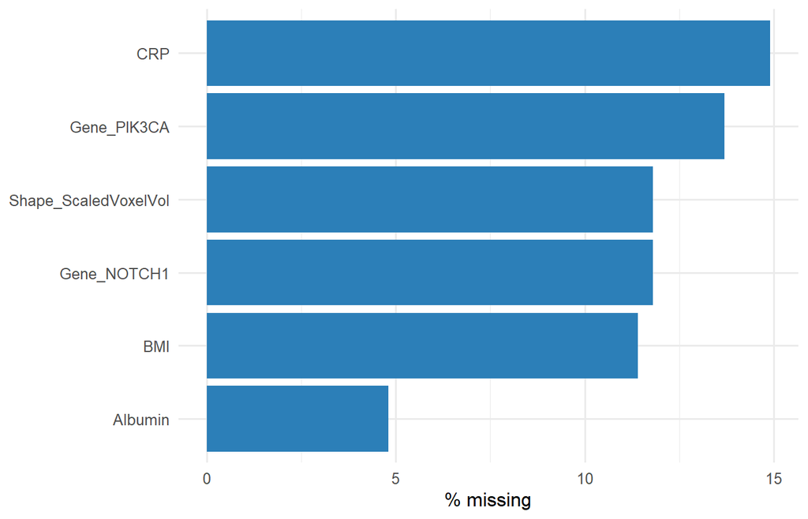

Percentage of missing values by variable

```r
ggplot(miss_tbl, aes(reorder(Variable, Percent), Percent)) +
  geom_col(fill = "#2C7FB8") + coord_flip() +
  labs(x = NULL, y = "% missing")
```

## 3.2 Physiologically impossible values

The core patient information can contain data-entry errors. Impossible values are **recoded as missing (`NA`)** inside the pre-processing recipe so that they are imputed, not learned from. The limits below are clinical, not data-driven, which avoids leakage.

```r
age_min <- 18;  age_max <- 110     # adult cohort; ages above 110 are impossible
bmi_min <- 10;  bmi_max <- 80      # BMI outside this range is not compatible with life
py_min  <- 0;   py_max  <- 200     # pack-years cannot be negative or implausibly large

limits <- tibble(Variable = c("Age", "BMI", "Pack_years"),
                 Lower = c(age_min, bmi_min, py_min),
                 Upper = c(age_max, bmi_max, py_max))

impossible <- pmap_dfr(limits, function(Variable, Lower, Upper) {
  x   <- DF[[Variable]]
  bad <- !is.na(x) & (x < Lower | x > Upper)
  tibble(Variable, Lower, Upper, n_impossible = sum(bad),
         values = paste(sort(unique(x[bad])), collapse = ", "))
})
kable(impossible, caption = "Impossible values detected, by clinical limits")
```

Impossible values detected, by clinical limits

| Variable | Lower | Upper | n_impossible | values |
| --- | --- | --- | --- | --- |
| Age | 18 | 110 | 5 | 5, 150, 250, 500, 999 |
| BMI | 10 | 80 | 5 | 0, 3.2, 120 |
| Pack_years | 0 | 200 | 4 | -12, -5, -1, 400 |

```r
# Same rules as the recipe, used only for exploratory plots
clean_impossible <- function(d) {
  d %>% mutate(
    Age        = ifelse(Age < age_min | Age > age_max, NA, Age),
    BMI        = ifelse(BMI < bmi_min | BMI > bmi_max, NA, BMI),
    Pack_years = ifelse(Pack_years < py_min | Pack_years > py_max, NA, Pack_years)
  )
}
```

# 4. Train/Test Split

A **stratified** 80/20 split keeps the mortality rate the same in both sets. The test set is not touched until the final evaluation.

```r
set.seed(1234)
idx   <- caret::createDataPartition(DF[[y_col]], p = 0.80, list = FALSE)
tr_DF <- DF[idx, , drop = FALSE]
te_DF <- DF[-idx, , drop = FALSE]

rbind(train = c(n = nrow(tr_DF), prop.table(table(tr_DF[[y_col]]))),
      test  = c(n = nrow(te_DF), prop.table(table(te_DF[[y_col]])))) %>%
  round(3) %>% kable(caption = "Size and class balance of each set")
```

Size and class balance of each set

|  | n | Died | Survived |
| --- | --- | --- | --- |
| train | 961 | 0.407 | 0.593 |
| test | 239 | 0.406 | 0.594 |

# 5. Exploratory Data Analysis (training set only)

## 5.1 Single-variable summaries (DescTools)

`DescTools::Desc()` gives the distribution, quantiles, skewness, kurtosis and extreme values, with plots. The impossible values (for example in `Age` and `BMI`) show up in the `lowest` and `highest` lines and in the plots.

```
──────────────────────────────────────────────────────────────────────────────
Describe tr_DF[, c("Age", "BMI", "Pack_years")] (data.frame):

data frame: 961 obs. of  3 variables
        855 complete cases (89.0%)

  Nr  Class  ColName     NAs          Levels
  1   int    Age           .
  2   num    BMI         106 (11.0%)
  3   int    Pack_years    .


──────────────────────────────────────────────────────────────────────────────
1 - Age (integer)

  length       n    NAs  unique     0s   mean  meanCI'
     961     961      0      60      0  63.76   61.52
          100.0%   0.0%           0.0%          66.00

     .05     .10    .25  median    .75    .90     .95
   46.00   49.00  55.00   63.00  69.00  74.00   78.00

   range      sd  vcoef     mad    IQR   skew    kurt
  994.00   35.38   0.55   10.38  14.00  21.32  529.80

lowest : 5, 33, 34, 35 (2), 36
highest: 88 (2), 150, 250, 500, 999

' 95%-CI (classic)
```

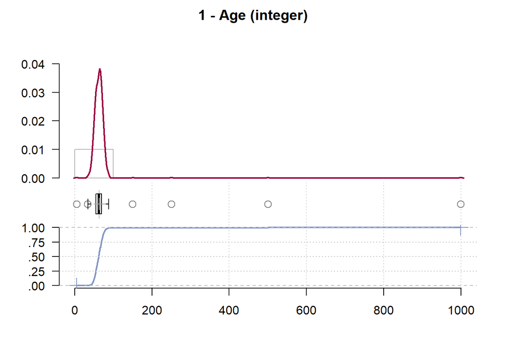

```
──────────────────────────────────────────────────────────────────────────────
2 - BMI (numeric)

  length      n    NAs  unique     0s   mean  meanCI'
     961    855    106     194      2  26.33   25.95
          89.0%  11.0%           0.2%          26.71

     .05    .10    .25  median    .75    .90     .95
   18.70  20.30  23.20   26.50  29.30  31.90   33.50

   range     sd  vcoef     mad    IQR   skew    kurt
  120.00   5.64   0.21    4.45   6.10   4.99   88.24

lowest : 0.0 (2), 3.2, 15.0 (4), 15.5 (2), 15.7
highest: 37.2, 37.6 (3), 37.8, 39.5, 120.0

' 95%-CI (classic)
```

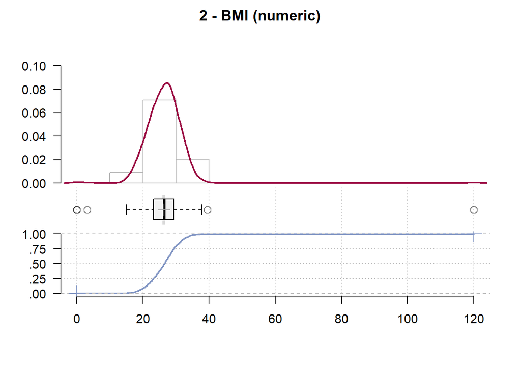

```
──────────────────────────────────────────────────────────────────────────────
3 - Pack_years (integer)

  length       n    NAs  unique     0s   mean  meanCI'
     961     961      0      72    307  18.06   16.76
          100.0%   0.0%          31.9%          19.36

     .05     .10    .25  median    .75    .90     .95
    0.00    0.00   0.00   17.00  28.00  40.00   47.00

   range      sd  vcoef     mad    IQR   skew    kurt
  405.00   20.57   1.14   22.24  28.00   7.01  121.89

lowest : -5, -1, 0 (307), 3, 4 (3)
highest: 70, 71, 74, 80 (2), 400

heap(?): remarkable frequency (31.9%) for the mode(s) (= 0)

' 95%-CI (classic)
```

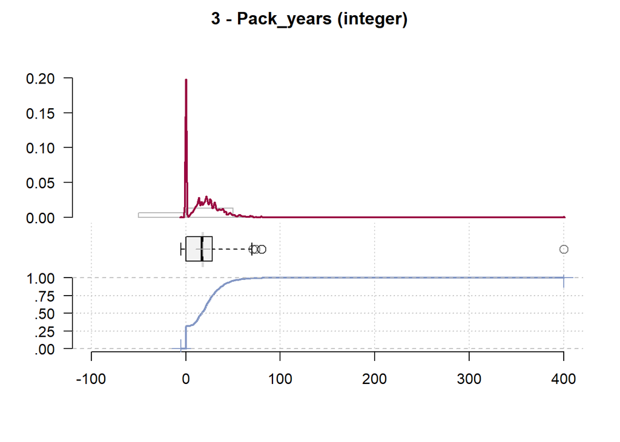

```r
DescTools::Desc(tr_DF[, c("Age", "BMI", "Pack_years")], plotit = TRUE)
```

```
──────────────────────────────────────────────────────────────────────────────
Describe tr_DF[, c("CRP", "Tumor_volume", "Albumin", "Smoking", "ECOG", "Tumor_subtype")] (data.frame):

data frame: 961 obs. of  6 variables
        780 complete cases (81.2%)

  Nr  Class  ColName        NAs          Levels
  1   num    CRP            145 (15.1%)
  2   num    Tumor_volume     .
  3   num    Albumin         42 (4.4%)
  4   chr    Smoking          .
  5   int    ECOG             .
  6   chr    Tumor_subtype    .


──────────────────────────────────────────────────────────────────────────────
1 - CRP (numeric)

  length      n    NAs  unique     0s   mean  meanCI'
     961    816    145     128      0  4.708   4.491
          84.9%  15.1%           0.0%          4.925

     .05    .10    .25  median    .75    .90     .95
   1.275  1.600  2.500   3.900  6.100  8.750  11.000

   range     sd  vcoef     mad    IQR   skew    kurt
  23.300  3.155  0.670   2.446  3.600  1.708   4.586

lowest : 0.5, 0.6, 0.7 (3), 0.8 (3), 0.9 (6)
highest: 17.2, 18.5, 21.4, 22.7, 23.8

' 95%-CI (classic)
```

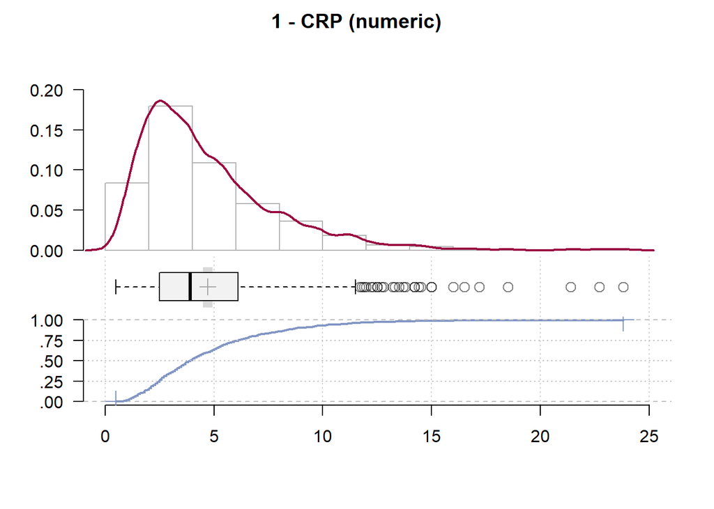

```
──────────────────────────────────────────────────────────────────────────────
2 - Tumor_volume (numeric)

  length       n    NAs  unique     0s   mean  meanCI'
     961     961      0     905      0  47.35   45.75
          100.0%   0.0%           0.0%          48.95

     .05     .10    .25  median    .75    .90     .95
   17.72   21.34  28.76   41.68  59.44  82.10  100.01

   range      sd  vcoef     mad    IQR   skew    kurt
  141.17   25.28   0.53   21.32  30.68   1.27    1.73

lowest : 8.83, 9.98, 11.33, 11.75, 12.08
highest: 136.61, 139.56, 145.74, 147.7, 150.0 (3)

' 95%-CI (classic)
```

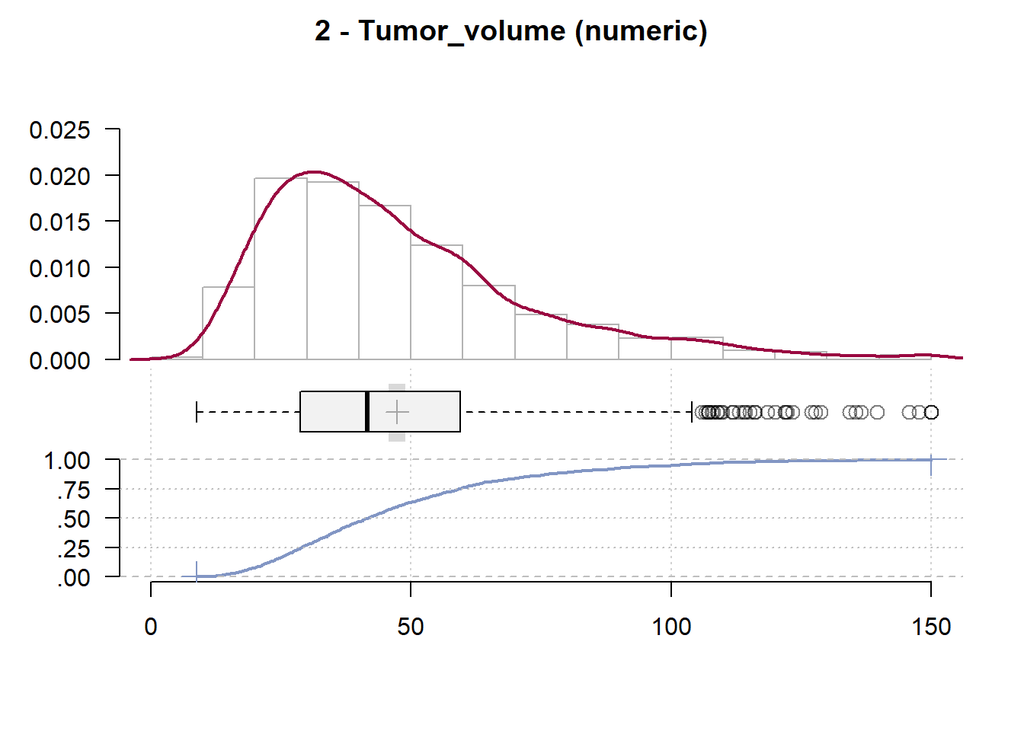

```
──────────────────────────────────────────────────────────────────────────────
3 - Albumin (numeric)

  length      n    NAs  unique    0s   mean  meanCI'
     961    919     42      30     0   3.96    3.93
          95.6%   4.4%          0.0%           4.00

     .05    .10    .25  median   .75    .90     .95
    3.10   3.30   3.60    4.00  4.30   4.60    4.81

   range     sd  vcoef     mad   IQR   skew    kurt
    3.10   0.51   0.13    0.44  0.70  -0.04   -0.18

lowest : 2.3, 2.4, 2.6 (3), 2.7 (3), 2.8 (4)
highest: 4.9 (18), 5.0 (15), 5.1 (3), 5.2 (8), 5.4 (2)

heap(?): remarkable frequency (7.8%) for the mode(s) (= 4.1)

' 95%-CI (classic)
```

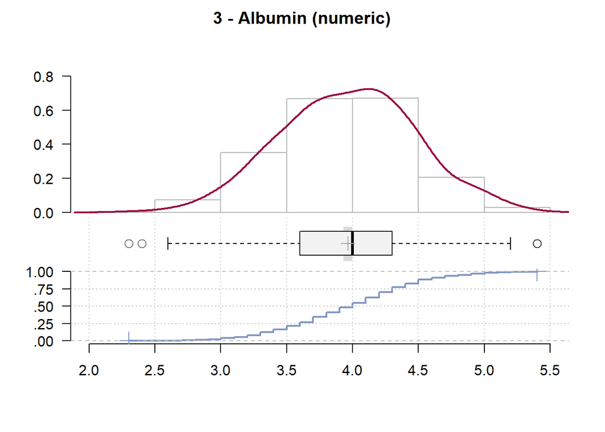

```
──────────────────────────────────────────────────────────────────────────────
4 - Smoking (character)

  length      n    NAs unique levels  dupes
     961    961      0      3      3      y
         100.0%   0.0%

     level  freq   perc  cumfreq  cumperc
1   Former   378  39.3%      378    39.3%
2    Never   308  32.0%      686    71.4%
3  Current   275  28.6%      961   100.0%
```

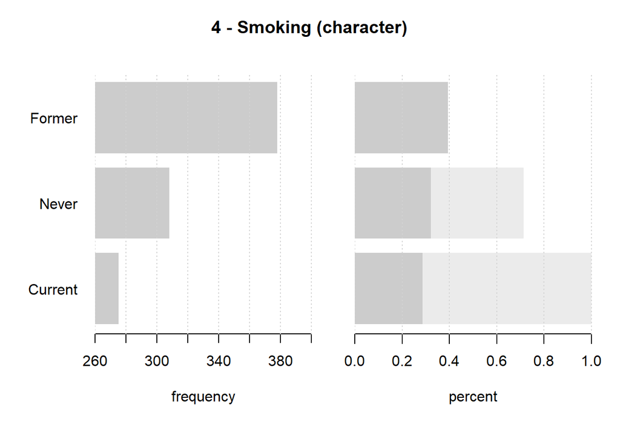

```
──────────────────────────────────────────────────────────────────────────────
5 - ECOG (integer)

  length       n    NAs  unique     0s  mean  meanCI'
     961     961      0       4    434  0.78    0.73
          100.0%   0.0%          45.2%          0.84

     .05     .10    .25  median    .75   .90     .95
    0.00    0.00   0.00    1.00   1.00  2.00    3.00

   range      sd  vcoef     mad    IQR  skew    kurt
    3.00    0.87   1.11    1.48   1.00  0.96    0.20


   value  freq   perc  cumfreq  cumperc
1      0   434  45.2%      434    45.2%
2      1   357  37.1%      791    82.3%
3      2   115  12.0%      906    94.3%
4      3    55   5.7%      961   100.0%

' 95%-CI (classic)
```

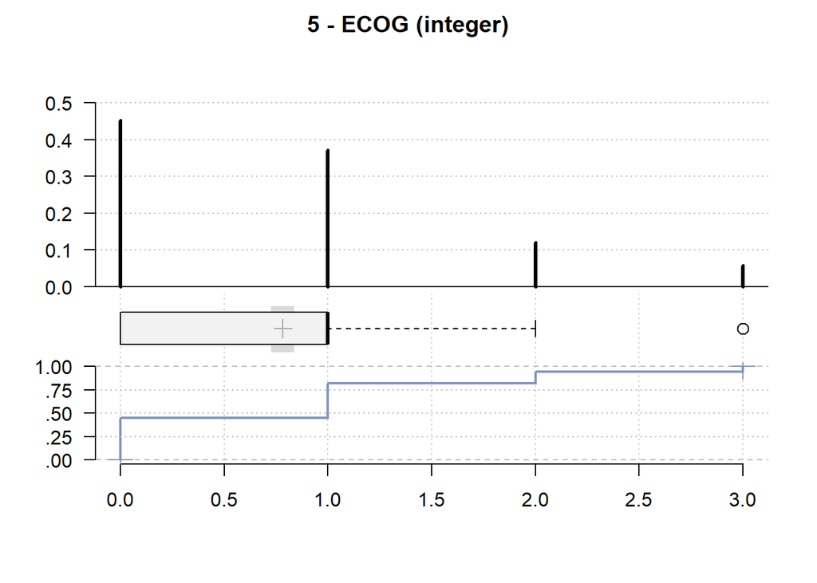

```
──────────────────────────────────────────────────────────────────────────────
6 - Tumor_subtype (character)

  length      n    NAs unique levels  dupes
     961    961      0      3      3      y
         100.0%   0.0%

       level  freq   perc  cumfreq  cumperc
1  Classical   422  43.9%      422    43.9%
2      Basal   327  34.0%      749    77.9%
3     Immune   212  22.1%      961   100.0%
```

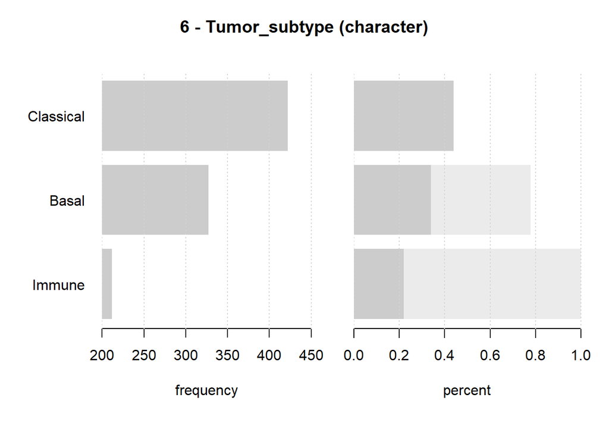

```r
DescTools::Desc(tr_DF[, c("CRP", "Tumor_volume", "Albumin", "Smoking", "ECOG", "Tumor_subtype")], plotit = TRUE)
```

## 5.2 Outcome versus predictors

```
──────────────────────────────────────────────────────────────────────────────
death5yr ~ Age (clean_impossible(tr_DF))

Summary:
n pairs: 961, valid: 956 (99.5%), missings: 5 (0.5%), groups: 2


            Died  Survived
mean      64.951    60.170
median    66.000    60.000
sd         9.293     9.394
IQR       13.000    13.000
n            387       569
np       40.481%   59.519%
NAs            4         1
0s             0         0

Kruskal-Wallis rank sum test:
  Kruskal-Wallis chi-squared = 57.71, df = 1, p-value = 3.038e-14





Proportions of death5yr in the quantiles of Age:

                Q1      Q2      Q3      Q4
  Died       24.6%   38.8%   44.2%   57.5%
  Survived   75.4%   61.2%   55.8%   42.5%
```

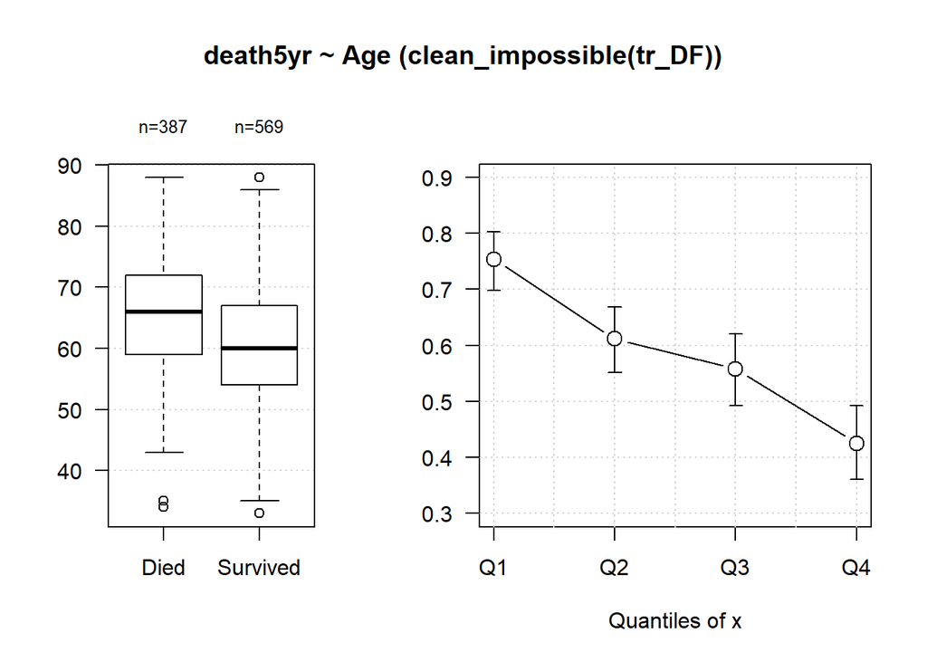

```
──────────────────────────────────────────────────────────────────────────────
death5yr ~ Smoking (clean_impossible(tr_DF))

Summary:
n: 961, rows: 3, columns: 2

Pearson's Chi-squared test:
  X-squared = 63.802, df = 2, p-value = 1.398e-14
Log likelihood ratio (G-test) test of independence:
  G = 65.436, X-squared df = 2, p-value = 6.217e-15
Mantel-Haenszel Chi-squared:
  X-squared = 63.432, df = 1, p-value = 1.66e-15

Contingency Coeff.     0.250
Cramer's V             0.258
Kendall Tau-b          0.243


          death5yr   Died   Survived    Sum
Smoking

Current   freq        156        119    275
          perc      16.2%      12.4%  28.6%
          p.row     56.7%      43.3%      .
          p.col     39.9%      20.9%      .

Former    freq        160        218    378
          perc      16.6%      22.7%  39.3%
          p.row     42.3%      57.7%      .
          p.col     40.9%      38.2%      .

Never     freq         75        233    308
          perc       7.8%      24.2%  32.0%
          p.row     24.4%      75.6%      .
          p.col     19.2%      40.9%      .

Sum       freq        391        570    961
          perc      40.7%      59.3% 100.0%
          p.row         .          .      .
          p.col         .          .      .
```

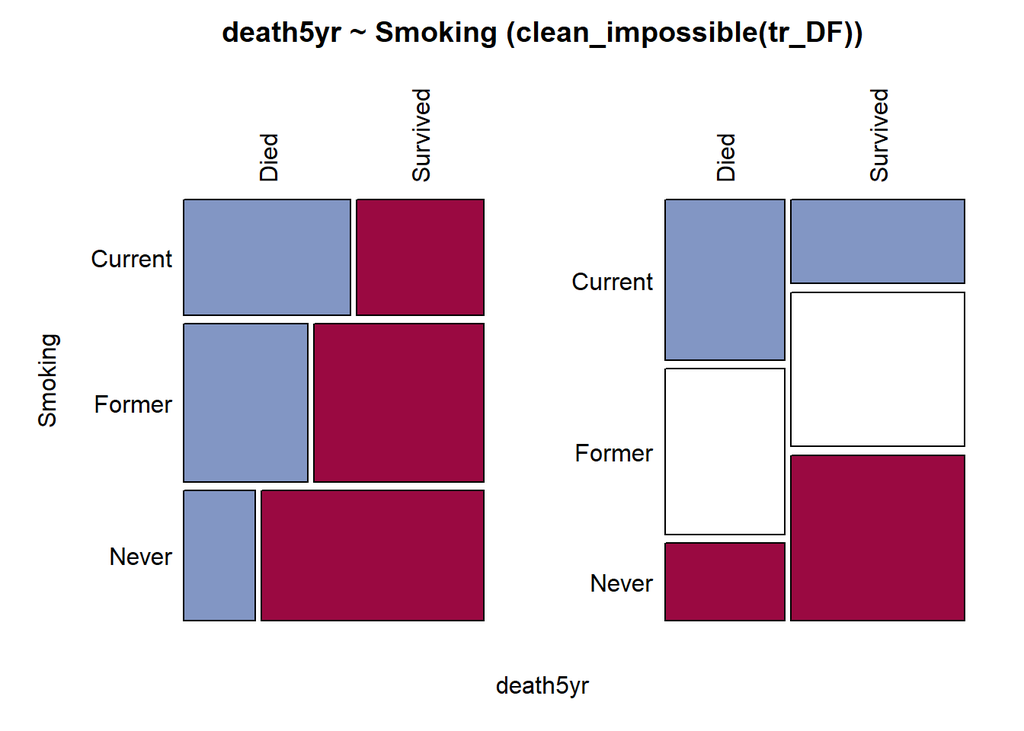

```
──────────────────────────────────────────────────────────────────────────────
death5yr ~ Tumor_subtype (clean_impossible(tr_DF))

Summary:
n: 961, rows: 3, columns: 2

Pearson's Chi-squared test:
  X-squared = 43.976, df = 2, p-value = 2.823e-10
Log likelihood ratio (G-test) test of independence:
  G = 45.472, X-squared df = 2, p-value = 1.336e-10
Mantel-Haenszel Chi-squared:
  X-squared = 43.402, df = 1, p-value = 4.456e-11

Contingency Coeff.     0.209
Cramer's V             0.214
Kendall Tau-b          0.200


                death5yr   Died   Survived    Sum
Tumor_subtype

Basal           freq        171        156    327
                perc      17.8%      16.2%  34.0%
                p.row     52.3%      47.7%      .
                p.col     43.7%      27.4%      .

Classical       freq        170        252    422
                perc      17.7%      26.2%  43.9%
                p.row     40.3%      59.7%      .
                p.col     43.5%      44.2%      .

Immune          freq         50        162    212
                perc       5.2%      16.9%  22.1%
                p.row     23.6%      76.4%      .
                p.col     12.8%      28.4%      .

Sum             freq        391        570    961
                perc      40.7%      59.3% 100.0%
                p.row         .          .      .
                p.col         .          .      .
```

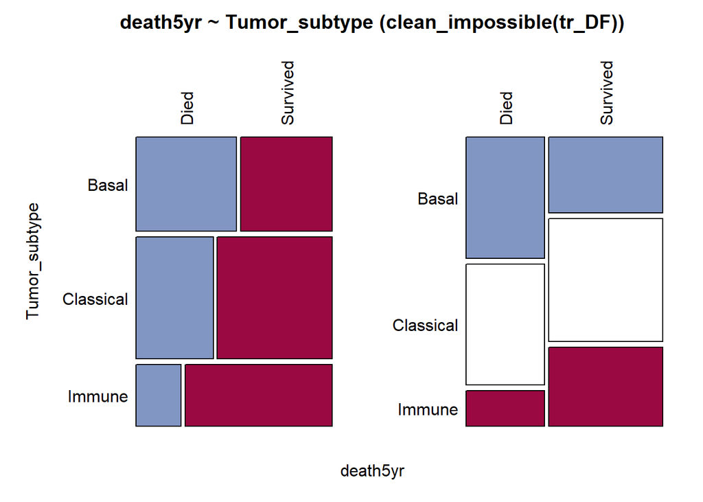

```r
DescTools::Desc(death5yr ~ Age + Smoking + Tumor_subtype, data = clean_impossible(tr_DF), plotit = TRUE)
```

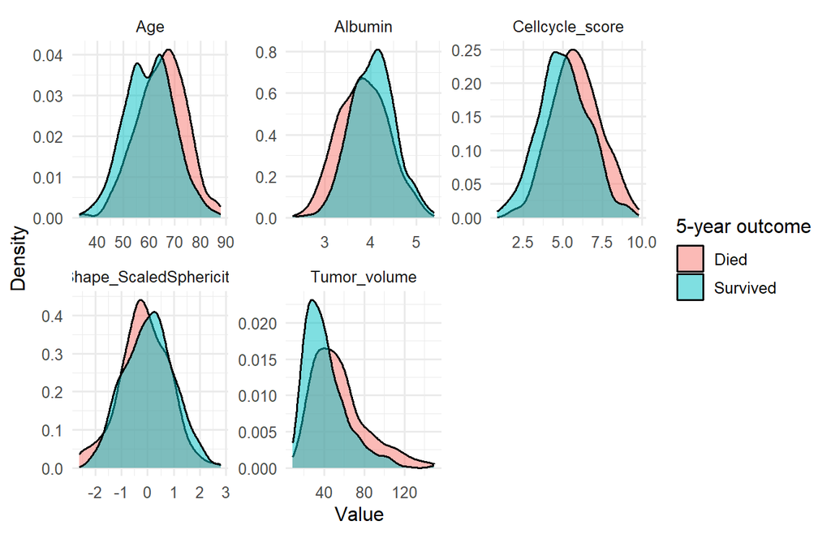

Distribution of key continuous predictors by outcome

```r
clean_tr <- clean_impossible(tr_DF)
clean_tr %>%
  select(all_of(y_col), Age, Tumor_volume, Cellcycle_score, Albumin, Shape_ScaledSphericity) %>%
  pivot_longer(-all_of(y_col), names_to = "Feature", values_to = "Value") %>%
  ggplot(aes(Value, fill = .data[[y_col]])) +
  geom_density(alpha = .5) +
  facet_wrap(~Feature, scales = "free") +
  labs(fill = "5-year outcome", y = "Density")
```

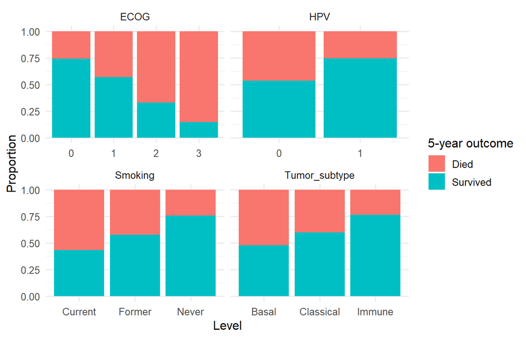

Mortality by categorical predictors

```r
tr_DF %>%
  select(all_of(c(y_col, "Smoking", "Tumor_subtype", "HPV", "ECOG"))) %>%
  mutate(across(c(HPV, ECOG), as.character)) %>%
  pivot_longer(-all_of(y_col), names_to = "Feature", values_to = "Level") %>%
  ggplot(aes(Level, fill = .data[[y_col]])) +
  geom_bar(position = "fill") +
  facet_wrap(~Feature, scales = "free_x") +
  labs(y = "Proportion", fill = "5-year outcome")
```

## 5.3 Skewness and correlation

```r
skew_tbl <- clean_tr %>%
  summarise(across(all_of(num_cols), ~ DescTools::Skew(.x, na.rm = TRUE))) %>%
  pivot_longer(everything(), names_to = "Variable", values_to = "Skewness") %>%
  arrange(desc(abs(Skewness)))
kable(head(skew_tbl, 8), digits = 2, caption = "Most skewed numeric predictors (candidates for Yeo-Johnson)")
```

Most skewed numeric predictors (candidates for Yeo-Johnson)

| Variable | Skewness |
| --- | --- |
| SNP_FBXW7 | 2.08 |
| CRP | 1.71 |
| SNP_AKT1 | 1.64 |
| SNP_PTEN | 1.63 |
| SNP_FAT1 | 1.52 |
| SNP_NOTCH1 | 1.50 |
| Tumor_volume | 1.27 |
| SNP_PIK3CA | 1.24 |

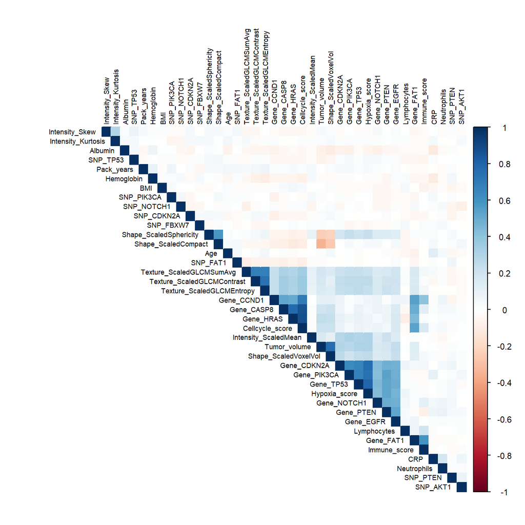

Correlation matrix of the numeric predictors

```r
M <- cor(clean_tr[, num_cols], use = "pairwise.complete.obs")
corrplot(M, method = "color", type = "upper", order = "hclust",
         tl.cex = 0.55, tl.col = "black", cl.cex = 0.7)
```

```r
as.data.frame(as.table(M)) %>%
  filter(as.integer(Var1) < as.integer(Var2), abs(Freq) > 0.7) %>%
  arrange(desc(abs(Freq))) %>%
  kable(digits = 2, col.names = c("Variable 1", "Variable 2", "Correlation"),
        caption = "Highly correlated pairs (|r| > 0.7): the reason for a correlation filter")
```

Highly correlated pairs (|r| > 0.7): the reason for a correlation filter

| Variable 1 | Variable 2 | Correlation |
| --- | --- | --- |
| Gene_HRAS | Cellcycle_score | 0.88 |
| Gene_CASP8 | Cellcycle_score | 0.87 |
| Gene_TP53 | Hypoxia_score | 0.79 |
| Gene_HRAS | Gene_CASP8 | 0.78 |
| Tumor_volume | Shape_ScaledVoxelVol | 0.77 |
| Gene_CDKN2A | Hypoxia_score | 0.76 |
| Gene_PIK3CA | Hypoxia_score | 0.75 |
| Texture_ScaledGLCMContrast | Texture_ScaledGLCMEntropy | 0.74 |
| Gene_CCND1 | Cellcycle_score | 0.71 |

# 6. Pre-processing with `recipes`

Every step is **estimated on the training data only** and then applied identically to any new data, so no information from the test set leaks into the model. Inside cross-validation, `caret` re-estimates the recipe within each fold.

| Step | Purpose |
| --- | --- |
| `step_rm(ID)` | Drop the identifier |
| `step_mutate` | Code types (HPV nominal, ECOG ordered) and set impossible values to `NA` |
| `step_string2factor`, `step_novel`, `step_unknown`, `step_other` | Safe handling of categories: unseen levels, missing labels, rare levels (< 1%) pooled |
| `step_impute_knn` | Multivariate KNN imputation (5 neighbours; Gower distance handles mixed data) |
| `step_ordinalscore` | ECOG as a numeric score |
| `step_dummy` | Dummy variables for nominal predictors |
| `step_zv`, `step_nzv` | Remove constant and near-constant predictors |
| `step_YeoJohnson` | Reduce skewness of continuous predictors |
| `step_center`, `step_scale` | Put all predictors on the same scale |
| `step_corr` | Drop one of each pair of predictors with \|r\| > 0.95 |

```r
mod_form <- as.formula(paste0(y_col, " ~ ."))
mod_form
```

```
death5yr ~ .
```

```r
rec <- recipe(mod_form, data = tr_DF) |>
  step_rm(ID) |>

  # Types, and impossible values -> NA so that they are imputed
  step_mutate(
    HPV  = as.character(HPV),
    ECOG = ordered(as.character(ECOG), levels = c("0", "1", "2", "3")),
    Age        = ifelse(Age < !!age_min | Age > !!age_max, NA, Age),
    BMI        = ifelse(BMI < !!bmi_min | BMI > !!bmi_max, NA, BMI),
    Pack_years = ifelse(Pack_years < !!py_min | Pack_years > !!py_max, NA, Pack_years)
  ) |>

  # Categorical safeguards
  step_string2factor(all_of(cat_cols)) |>
  step_novel(all_of(cat_cols), new_level = "NewLvl") |>
  step_unknown(all_of(cat_cols), new_level = "Unknown") |>
  step_other(all_of(cat_cols), threshold = 0.01, other = "OtherLvl") |>

  # Multivariate KNN imputation
  step_impute_knn(all_predictors(), neighbors = 5) |>

  # Ordinal score, then dummy encoding
  step_ordinalscore(all_of(ord_cols)) |>
  step_dummy(all_nominal_predictors(), one_hot = FALSE) |>

  # Stability filters
  step_zv(all_predictors()) |>
  step_nzv(all_predictors()) |>

  # Skewness correction for continuous / ordinal features only (any_of: tolerant if a step removed a column)
  step_YeoJohnson(any_of(num_cols), any_of(ord_cols)) |>

  # Centre and scale continuous and ordinal predictors (dummies stay 0/1)
  step_center(all_numeric_predictors()) |>
  step_scale(all_numeric_predictors()) |>

  # Multicollinearity filter
  step_corr(all_numeric_predictors(), threshold = 0.95)

rec
```

## Check what the recipe does

```r
rec_prep <- prep(rec, training = tr_DF)
baked    <- bake(rec_prep, new_data = NULL)

step_ids <- function(cls) which(map_chr(rec_prep$steps, ~ class(.x)[1]) == cls)
dropped  <- function(cls) tidy(rec_prep, number = step_ids(cls))$terms

tibble(Item = c("Predictors before pre-processing", "Predictors after pre-processing",
                "Missing values remaining", "Removed by near-zero variance filter",
                "Removed by correlation filter"),
       Value = c(length(X_cols), ncol(baked) - 1, sum(is.na(baked)),
                 paste(dropped("step_nzv"), collapse = ", ") %>% ifelse(. == "", "none", .),
                 paste(dropped("step_corr"), collapse = ", ") %>% ifelse(. == "", "none", .))) %>%
  kable(caption = "Effect of the pre-processing recipe on the training set")
```

Effect of the pre-processing recipe on the training set

| Item | Value |
| --- | --- |
| Predictors before pre-processing | 45 |
| Predictors after pre-processing | 49 |
| Missing values remaining | 0 |
| Removed by near-zero variance filter | Country_Norway, Country_OtherLvl |
| Removed by correlation filter | none |

# 7. Cross-Validation Strategy

All models use **the same five stratified folds**, so their cross-validated results are directly comparable. Tuning optimises the area under the ROC curve (AUC), which does not depend on a probability threshold.

```r
set.seed(1234)
folds <- caret::createFolds(tr_DF[[y_col]], k = 5, returnTrain = TRUE)

# AUC, sensitivity, specificity (twoClassSummary) plus accuracy and kappa
fiveStats <- function(data, lev = NULL, model = NULL) {
  c(caret::twoClassSummary(data, lev, model), caret::defaultSummary(data, lev, model))
}

ctrl <- caret::trainControl(
  method = "cv", number = 5, index = folds,
  classProbs = TRUE, summaryFunction = fiveStats,
  search = "grid", selectionFunction = "best",
  savePredictions = "final", verboseIter = FALSE,
  allowParallel = use_parallel
)
```

# 8. Model Training

Ten algorithms from five families are tuned on small grids. If one model fails to fit, it is reported and skipped so the rest of the report still runs.

| Family | Method (`caret`) | Tuned parameters |
| --- | --- | --- |
| Linear | `glmnet` (elastic net), `pls` | `alpha`, `lambda`; `ncomp` |
| Generative | `rda`, `nb` | `gamma`, `lambda`; `fL`, `usekernel`, `adjust` |
| Distance-based | `knn`, `pam` | `k`; `threshold` |
| Tree ensembles | `gbm`, `xgbTree` (custom model) | trees, depth, learning rate, …; boosting rounds, depth, `eta`, `gamma`, column/row sampling, `min_child_weight` |
| Neural networks | `nnet`, `mlp` | `size`, `decay`; `size` |

## 8.1 A custom `caret` model for XGBoost

`caret`’s built-in `xgbTree` fails with recent `xgboost` releases (3.x): it tries to store extra information inside the booster object, which the new object type does not allow (`ALTLIST classes must provide a Set_elt method`). The custom model below keeps the booster inside an ordinary list, so it works with both old and new versions of `xgboost`. The event class is the first factor level (`"Died"`), and the booster is also stored as raw bytes so that a model cached with `saveRDS()` can be restored in a later R session.

```r
# Predicted probability of the event class (first factor level), robust to a cached model:
# if the booster handle is no longer valid after readRDS(), rebuild it from the raw bytes.
xgb_p1 <- function(modelFit, newdata) {
  X <- as.matrix(newdata)
  tryCatch(
    as.numeric(predict(modelFit$booster, X)),
    error = function(e) as.numeric(predict(xgboost::xgb.load.raw(modelFit$raw), X))
  )
}

xgbTree_3x <- list(
  label   = "XGBoost Tree (xgboost >= 3.x, caret custom)",
  library = "xgboost",
  type    = "Classification",

  parameters = data.frame(
    parameter = c("nrounds", "max_depth", "eta", "gamma", "colsample_bytree", "min_child_weight", "subsample"),
    class     = rep("numeric", 7),
    label     = c("Boosting Iterations", "Max Tree Depth", "Shrinkage", "Gamma",
                  "Subsample Ratio of Columns", "Min Child Weight", "Subsample Ratio of Rows"),
    stringsAsFactors = FALSE
  ),

  # caret needs a 'grid' function for custom models (even if tuneGrid is supplied)
  grid = function(x, y, len = NULL, search = "grid") {
    if (is.null(len)) len <- 3
    if (search == "grid") {
      expand.grid(
        nrounds = round(seq(100, 400, length.out = len)),
        max_depth = unique(round(seq(2, 6, length.out = len))),
        eta = c(0.05, 0.1)[1:min(2, len)],
        gamma = c(0, 1)[1:min(2, len)],
        colsample_bytree = 0.8,
        min_child_weight = 1,
        subsample = 0.8
      )
    } else {
      data.frame(
        nrounds = sample(seq(100, 800, by = 50), len, replace = TRUE),
        max_depth = sample(2:8, len, replace = TRUE),
        eta = exp(runif(len, log(0.01), log(0.3))),
        gamma = runif(len, 0, 5),
        colsample_bytree = runif(len, 0.5, 1.0),
        min_child_weight = runif(len, 1, 10),
        subsample = runif(len, 0.5, 1.0)
      )
    }
  },

  loop = NULL,

  fit = function(x, y, wts, param, lev, last, classProbs, ...) {
    dots <- list(...)
    X    <- as.matrix(x)
    y01  <- as.numeric(y == lev[1])            # lev[1] is the event class ("Died")
    dtrain <- xgboost::xgb.DMatrix(data = X, label = y01)

    user_params <- dots$params
    if (is.null(user_params)) user_params <- list()

    params <- modifyList(
      list(
        objective        = "binary:logistic",
        eval_metric      = "auc",
        eta              = param$eta,
        max_depth        = as.integer(param$max_depth),
        gamma            = param$gamma,
        colsample_bytree = param$colsample_bytree,
        min_child_weight = param$min_child_weight,
        subsample        = param$subsample
      ),
      user_params
    )

    bst <- xgboost::xgb.train(
      params  = params,
      data    = dtrain,
      nrounds = as.integer(param$nrounds),
      verbose = 0
    )

    list(booster = bst,
         raw     = tryCatch(xgboost::xgb.save.raw(bst), error = function(e) NULL),
         lev     = lev,
         xNames  = colnames(X))
  },

  prob = function(modelFit, newdata, submodels = NULL) {
    p1  <- xgb_p1(modelFit, newdata)
    out <- data.frame(tmp1 = p1, tmp2 = 1 - p1)
    colnames(out) <- modelFit$lev
    out
  },

  predict = function(modelFit, newdata, submodels = NULL) {
    p1 <- xgb_p1(modelFit, newdata)
    factor(ifelse(p1 >= 0.5, modelFit$lev[1], modelFit$lev[2]), levels = modelFit$lev)
  },

  levels = function(x) x$lev,
  sort   = function(x) x[order(x[, 1]), ]
)
```

## 8.2 Tuning grids and the fitting function

```r
model_specs <- list(
  glmnet = list(method = "glmnet",
                grid = expand.grid(alpha = c(0, 0.25, 0.5, 0.75, 1),
                                   lambda = 10^seq(-4, -0.5, length.out = 10)),
                args = list()),
  pls    = list(method = "pls",
                grid = data.frame(ncomp = 1:12),
                args = list()),
  rda    = list(method = "rda",
                grid = expand.grid(gamma = c(0, 0.25, 0.5, 0.75, 1),
                                   lambda = c(0.25, 0.5, 0.75, 1)),
                args = list()),
  nb     = list(method = "nb",
                grid = expand.grid(fL = 1, usekernel = TRUE, adjust = c(1, 1.5, 2)),   # kernel densities + Laplace smoothing avoid zero probabilities
                args = list()),
  knn    = list(method = "knn",
                grid = data.frame(k = seq(5, 45, by = 4)),
                args = list()),
  pam    = list(method = "pam",
                grid = data.frame(threshold = seq(0, 3, length.out = 15)),
                args = list()),
  gbm    = list(method = "gbm",
                grid = expand.grid(n.trees = c(100, 200, 300), interaction.depth = 1:3, shrinkage = c(0.01, 0.05, 0.1), n.minobsinnode = c(10, 20)), args = list(verbose = FALSE)),

  xgbTree = list(method = xgbTree_3x, # the custom model defined above
                 grid = expand.grid(nrounds = c(100, 200), max_depth = c(2, 3, 4), eta = c(0.03, 0.1), gamma = 0, colsample_bytree = c(0.6, 0.8), min_child_weight = c(1, 5), subsample = c(0.7, 0.9)),
                 args = list()),

  nnet   = list(method = "nnet",
                grid = expand.grid(size = c(1, 3, 5, 7), decay = c(0.01, 0.1, 1)),
                args = list(trace = FALSE, maxit = 300, MaxNWts = 5000)),
  mlp    = list(method = "mlp",
                grid = data.frame(size = c(1, 3, 5, 7)),
                args = list())
)

fit_one <- function(name, spec) {
  message(">> Training: ", name)
  run <- function() {
    set.seed(1234)  # same seed for every model
    do.call(caret::train,
            c(list(x = rec, data = tr_DF, method = spec$method, metric = "ROC", trControl = ctrl, tuneGrid = spec$grid), spec$args))
  }
  # A single failing model must not stop the whole report: report it and carry on.
  # Naive Bayes warns about "0 probability" for extreme observations; that is expected noise.
  tryCatch(if (name == "nb") suppressWarnings(run()) else run(),
           error = function(e) { message("!! ", name, " failed: ", conditionMessage(e)); NULL })
}
```

Training takes several minutes. The fitted models are cached in `output/models.rds`, so re-rendering the report is fast. Delete the file to force a re-fit.

```r
dir.create(here::here("output"), showWarnings = FALSE)
models_path <- here::here("output", "models.rds")

if (file.exists(models_path)) {
  models <- readRDS(models_path)
} else {
  models <- imap(model_specs, function(spec, name) fit_one(name, spec))
  failed <- names(models)[map_lgl(models, is.null)]
  models <- compact(models)                       # drop models that failed to fit
  if (length(failed)) {
    message("Models that failed and were dropped: ", paste(failed, collapse = ", "))
  } else {
    saveRDS(models, models_path)                  # cache only when every model fitted
  }
}
names(models)
```

```
 [1] "glmnet"  "pls"     "rda"     "nb"      "knn"     "pam"     "gbm"
 [8] "xgbTree" "nnet"    "mlp"
```

# 9. Model comparison

## 9.1 Cross-validated performance

```r
cv_tbl <- map_dfr(models, caret::getTrainPerf, .id = "Model") %>%
  transmute(Model, ROC = TrainROC, Sensitivity = TrainSens, Specificity = TrainSpec,
            Accuracy = TrainAccuracy, Kappa = TrainKappa) %>%
  arrange(desc(ROC))
kable(cv_tbl, digits = 3, caption = "5-fold cross-validated performance of the tuned models (training set)")
```

5-fold cross-validated performance of the tuned models (training set)

| Model | ROC | Sensitivity | Specificity | Accuracy | Kappa |
| --- | --- | --- | --- | --- | --- |
| pls | 0.842 | 0.691 | 0.826 | 0.771 | 0.521 |
| glmnet | 0.842 | 0.652 | 0.835 | 0.761 | 0.496 |
| rda | 0.842 | 0.678 | 0.828 | 0.767 | 0.512 |
| nnet | 0.837 | 0.683 | 0.812 | 0.760 | 0.498 |
| xgbTree | 0.830 | 0.657 | 0.819 | 0.753 | 0.483 |
| gbm | 0.824 | 0.614 | 0.823 | 0.738 | 0.446 |
| knn | 0.816 | 0.534 | 0.905 | 0.754 | 0.463 |
| nb | 0.808 | 0.596 | 0.839 | 0.740 | 0.446 |
| mlp | 0.805 | 0.678 | 0.798 | 0.749 | 0.478 |
| pam | 0.803 | 0.547 | 0.858 | 0.732 | 0.422 |

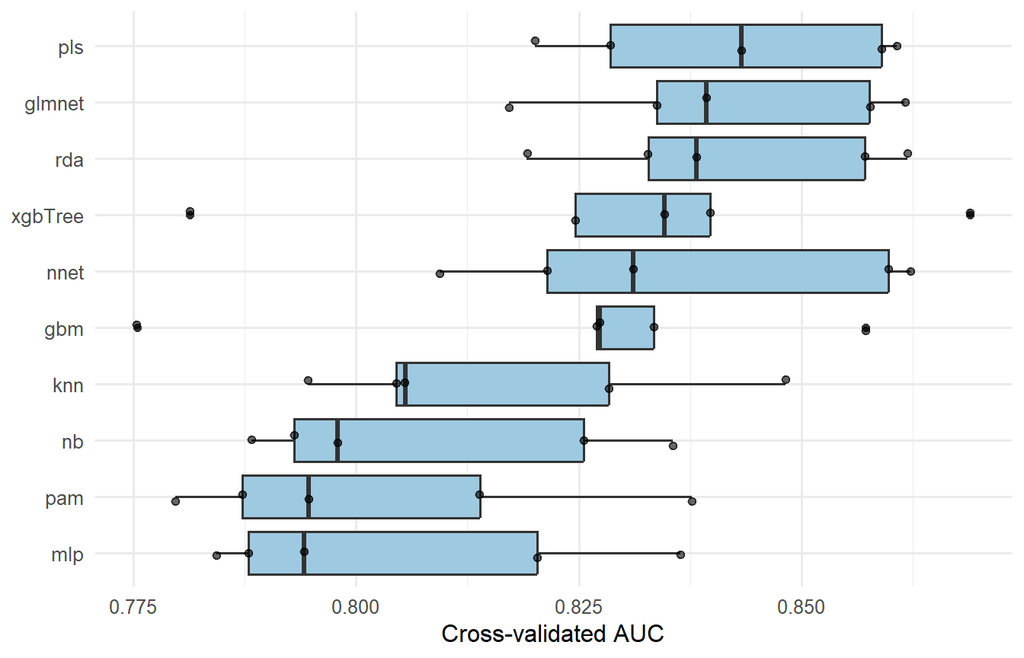

Cross-validated AUC across the five folds

```r
rs <- caret::resamples(models)
rs$values %>%
  dplyr::select(Resample, ends_with("~ROC")) %>%
  pivot_longer(-Resample, names_to = "Model", values_to = "ROC") %>%
  mutate(Model = sub("~ROC", "", Model)) %>%
  ggplot(aes(reorder(Model, ROC, median), ROC)) +
  geom_boxplot(fill = "#9ECAE1") +
  geom_jitter(width = .1, alpha = .6) +
  coord_flip() +
  labs(x = NULL, y = "Cross-validated AUC")
```

```r
best_tune <- map_dfr(models, function(m) {
  bt <- m$bestTune
  tibble(`Selected hyper-parameters` = paste(names(bt), unlist(bt), sep = " = ", collapse = ", "))
}, .id = "Model")
kable(best_tune, caption = "Hyper-parameters selected by cross-validation")
```

Hyper-parameters selected by cross-validation

| Model | Selected hyper-parameters |
| --- | --- |
| glmnet | alpha = 0, lambda = 0.0527499706370262 |
| pls | ncomp = 2 |
| rda | gamma = 0.25, lambda = 1 |
| nb | fL = 1, usekernel = 1, adjust = 2 |
| knn | k = 41 |
| pam | threshold = 0.428571428571429 |
| gbm | n.trees = 100, interaction.depth = 2, shrinkage = 0.1, n.minobsinnode = 20 |
| xgbTree | nrounds = 200, max_depth = 4, eta = 0.1, gamma = 0, colsample_bytree = 0.6, min_child_weight = 1, subsample = 0.7 |
| nnet | size = 1, decay = 1 |
| mlp | size = 1 |

## 9.2 Training and test performance of every model

```r
perf_metrics <- function(fit, newdata) {
  prob <- predict(fit, newdata, type = "prob")[["Died"]]
  cls  <- predict(fit, newdata)
  cm   <- caret::confusionMatrix(cls, newdata[[y_col]], positive = "Died")
  auc  <- as.numeric(pROC::auc(pROC::roc(newdata[[y_col]], prob,
                                         levels = c("Survived", "Died"), direction = "<", quiet = TRUE)))
  tibble(Accuracy = cm$overall[["Accuracy"]],
         `Balanced accuracy` = cm$byClass[["Balanced Accuracy"]],
         Sensitivity = cm$byClass[["Sensitivity"]],
         Specificity = cm$byClass[["Specificity"]],
         PPV = cm$byClass[["Pos Pred Value"]],
         NPV = cm$byClass[["Neg Pred Value"]],
         Kappa = cm$overall[["Kappa"]],
         AUC = auc)
}
```

```r
perf_te <- map_dfr(models, ~ perf_metrics(.x, te_DF), .id = "Model") %>% arrange(desc(AUC))
perf_tr <- map_dfr(models, ~ perf_metrics(.x, tr_DF), .id = "Model") %>% arrange(desc(AUC))

kable(perf_te, digits = 3, caption = "Test-set performance (unseen data; threshold 0.5)")
```

Test-set performance (unseen data; threshold 0.5)

| Model | Accuracy | Balanced accuracy | Sensitivity | Specificity | PPV | NPV | Kappa | AUC |
| --- | --- | --- | --- | --- | --- | --- | --- | --- |
| gbm | 0.782 | 0.758 | 0.629 | 0.887 | 0.792 | 0.778 | 0.534 | 0.799 |
| nnet | 0.715 | 0.694 | 0.577 | 0.810 | 0.675 | 0.737 | 0.396 | 0.794 |
| glmnet | 0.715 | 0.687 | 0.536 | 0.838 | 0.693 | 0.726 | 0.388 | 0.793 |
| rda | 0.720 | 0.697 | 0.577 | 0.817 | 0.683 | 0.739 | 0.404 | 0.792 |
| xgbTree | 0.741 | 0.716 | 0.588 | 0.845 | 0.722 | 0.750 | 0.446 | 0.789 |
| mlp | 0.749 | 0.733 | 0.649 | 0.817 | 0.708 | 0.773 | 0.473 | 0.788 |
| pls | 0.745 | 0.722 | 0.598 | 0.845 | 0.725 | 0.755 | 0.456 | 0.781 |
| nb | 0.711 | 0.675 | 0.485 | 0.866 | 0.712 | 0.711 | 0.369 | 0.769 |
| pam | 0.711 | 0.672 | 0.464 | 0.880 | 0.726 | 0.706 | 0.365 | 0.769 |
| knn | 0.728 | 0.693 | 0.505 | 0.880 | 0.742 | 0.723 | 0.406 | 0.769 |

```r
kable(perf_tr, digits = 3, caption = "Training-set performance (apparent performance)")
```

Training-set performance (apparent performance)

| Model | Accuracy | Balanced accuracy | Sensitivity | Specificity | PPV | NPV | Kappa | AUC |
| --- | --- | --- | --- | --- | --- | --- | --- | --- |
| xgbTree | 1.000 | 1.000 | 1.000 | 1.000 | 1.000 | 1.000 | 1.000 | 1.000 |
| gbm | 0.836 | 0.820 | 0.737 | 0.904 | 0.840 | 0.833 | 0.653 | 0.920 |
| nnet | 0.814 | 0.802 | 0.742 | 0.863 | 0.788 | 0.830 | 0.610 | 0.874 |
| glmnet | 0.795 | 0.780 | 0.698 | 0.861 | 0.776 | 0.806 | 0.569 | 0.871 |
| rda | 0.793 | 0.780 | 0.711 | 0.849 | 0.764 | 0.811 | 0.566 | 0.871 |
| pls | 0.795 | 0.783 | 0.721 | 0.846 | 0.762 | 0.816 | 0.572 | 0.861 |
| mlp | 0.852 | 0.845 | 0.803 | 0.886 | 0.828 | 0.868 | 0.692 | 0.853 |
| nb | 0.766 | 0.741 | 0.606 | 0.875 | 0.769 | 0.764 | 0.498 | 0.842 |
| knn | 0.755 | 0.725 | 0.560 | 0.889 | 0.777 | 0.747 | 0.470 | 0.842 |
| pam | 0.743 | 0.715 | 0.568 | 0.863 | 0.740 | 0.744 | 0.447 | 0.814 |

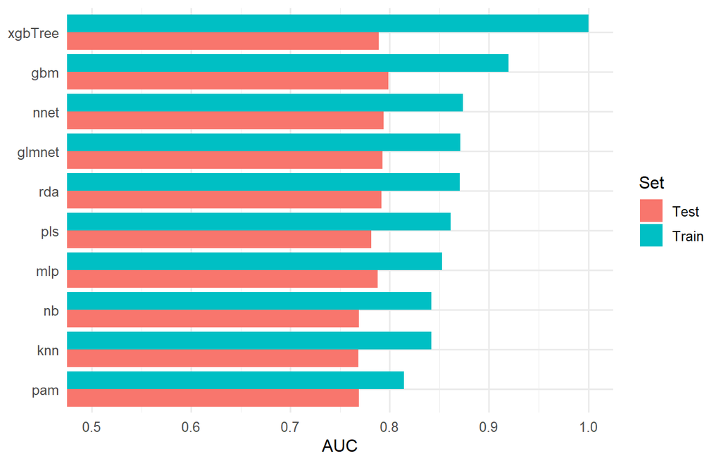

Training versus test AUC: a large gap indicates over-fitting

```r
bind_rows(Train = perf_tr, Test = perf_te, .id = "Set") %>%
  ggplot(aes(reorder(Model, AUC), AUC, fill = Set)) +
  geom_col(position = "dodge") +
  coord_flip(ylim = c(0.5, 1)) +
  labs(x = NULL, y = "AUC")
```

# 10. Final Model

The final model is selected using **cross-validated AUC on the training set**, not the test set. The test set is then used once to report generalisation, so the test estimate stays unbiased.

```r
best_name <- cv_tbl$Model[which.max(cv_tbl$ROC)]
fit_final <- models[[best_name]]
best_name
```

```
[1] "pls"
```

```r
fit_final
```

```
Partial Least Squares

961 samples
 46 predictor
  2 classes: 'Died', 'Survived'

Recipe steps: rm, mutate, string2factor, novel, unknown, other,
 impute_knn, ordinalscore, dummy, zv, nzv, YeoJohnson, center, scale, corr
Resampling: Cross-Validated (5 fold)
Summary of sample sizes: 769, 769, 769, 768, 769
Resampling results across tuning parameters:

  ncomp  ROC        Sens       Spec       Accuracy   Kappa
   1     0.8008205  0.5982473  0.8157895  0.7273370  0.4228449
   2     0.8422824  0.6905875  0.8263158  0.7710708  0.5213166
   3     0.8412540  0.6649789  0.8385965  0.7679458  0.5115640
   4     0.8387457  0.6624148  0.8298246  0.7617066  0.4992317
   5     0.8375607  0.6803635  0.8298246  0.7690037  0.5159941
   6     0.8370124  0.6778319  0.8210526  0.7627591  0.5035059
   7     0.8373759  0.6803635  0.8192982  0.7627537  0.5038724
   8     0.8370616  0.6752353  0.8228070  0.7627483  0.5029573
   9     0.8363635  0.6726712  0.8228070  0.7617066  0.5005004
  10     0.8355535  0.6777994  0.8210526  0.7627483  0.5033659
  11     0.8353055  0.6701071  0.8210526  0.7596233  0.4962229
  12     0.8349474  0.6701071  0.8210526  0.7596233  0.4962229

ROC was used to select the optimal model using the largest value.
The final value used for the model was ncomp = 2.
```

The selected model is **pls** (cross-validated AUC = 0.842).

## 10.1 Performance on training and test data

```r
tr_class <- predict(fit_final, newdata = tr_DF)
tr_prob  <- predict(fit_final, newdata = tr_DF, type = "prob")[["Died"]]
te_class <- predict(fit_final, newdata = te_DF)
te_prob  <- predict(fit_final, newdata = te_DF, type = "prob")[["Died"]]

roc_tr <- pROC::roc(tr_DF[[y_col]], tr_prob, levels = c("Survived", "Died"), direction = "<", quiet = TRUE)
roc_te <- pROC::roc(te_DF[[y_col]], te_prob, levels = c("Survived", "Died"), direction = "<", quiet = TRUE)
ci_te  <- pROC::ci.auc(roc_te)

cm_tr <- caret::confusionMatrix(tr_class, tr_DF[[y_col]], positive = "Died")
cm_te <- caret::confusionMatrix(te_class, te_DF[[y_col]], positive = "Died")

bind_rows(Train = perf_metrics(fit_final, tr_DF), Test = perf_metrics(fit_final, te_DF), .id = "Set") %>%
  kable(digits = 3, caption = "Final model: performance at the default 0.5 threshold")
```

Final model: performance at the default 0.5 threshold

| Set | Accuracy | Balanced accuracy | Sensitivity | Specificity | PPV | NPV | Kappa | AUC |
| --- | --- | --- | --- | --- | --- | --- | --- | --- |
| Train | 0.795 | 0.783 | 0.721 | 0.846 | 0.762 | 0.816 | 0.572 | 0.861 |
| Test | 0.745 | 0.722 | 0.598 | 0.845 | 0.725 | 0.755 | 0.456 | 0.781 |

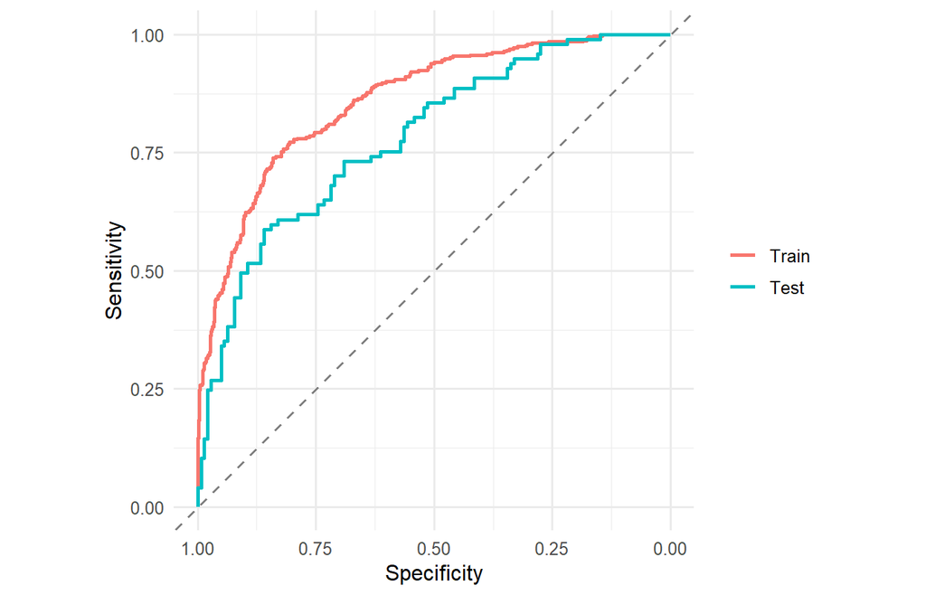

ROC curves of the final model

```r
pROC::ggroc(list(Train = roc_tr, Test = roc_te), linewidth = 1) +
  geom_abline(intercept = 1, slope = 1, linetype = "dashed", colour = "grey50") +
  coord_equal() +
  labs(x = "Specificity", y = "Sensitivity", colour = NULL)
```

```r
cat("--- Test set confusion matrix ---\n")
```

```
--- Test set confusion matrix ---
```

```r
print(cm_te)
```

```
Confusion Matrix and Statistics

          Reference
Prediction Died Survived
  Died       58       22
  Survived   39      120

               Accuracy : 0.7448
                 95% CI : (0.6846, 0.7988)
    No Information Rate : 0.5941
    P-Value [Acc > NIR] : 7.649e-07

                  Kappa : 0.4557

 Mcnemar's Test P-Value : 0.0405

            Sensitivity : 0.5979
            Specificity : 0.8451
         Pos Pred Value : 0.7250
         Neg Pred Value : 0.7547
             Prevalence : 0.4059
         Detection Rate : 0.2427
   Detection Prevalence : 0.3347
      Balanced Accuracy : 0.7215

       'Positive' Class : Died
```

On the test set the final model achieved an AUC of **0.781** (95% CI 0.723 to 0.840), accuracy 0.745, sensitivity 0.598 and specificity 0.845. The training AUC was 0.861.

## 10.2 Calibration

A well-calibrated model produces predicted probabilities that match the observed event rates. Patients are grouped into deciles of predicted risk.

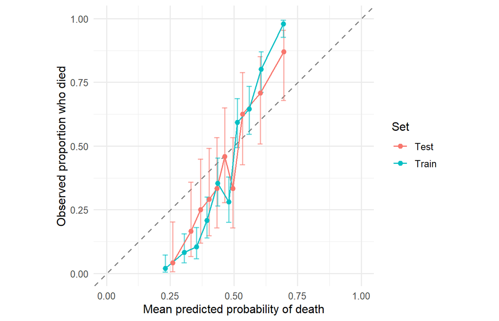

Calibration of the final model (deciles of predicted risk, 95% confidence intervals)

```r
calib <- bind_rows(
  tibble(Set = "Train", prob = tr_prob, obs = as.integer(tr_DF[[y_col]] == "Died")),
  tibble(Set = "Test",  prob = te_prob, obs = as.integer(te_DF[[y_col]] == "Died"))
) %>%
  dplyr::group_by(Set) %>%
  mutate(bin = ntile(prob, 10)) %>%
  group_by(Set, bin) %>%
  summarise(n = n(), deaths = sum(obs),
            predicted = mean(prob), observed = mean(obs), .groups = "drop") %>%
  mutate(lower = DescTools::BinomCI(deaths, n, method = "wilson")[, "lwr.ci"],
         upper = DescTools::BinomCI(deaths, n, method = "wilson")[, "upr.ci"])

ggplot(calib, aes(predicted, observed, colour = Set)) +
  geom_abline(intercept = 0, slope = 1, linetype = "dashed", colour = "grey50") +
  geom_errorbar(aes(ymin = lower, ymax = upper), width = .02, alpha = .6) +
  geom_line() + geom_point(size = 2) +
  coord_equal(xlim = c(0, 1), ylim = c(0, 1)) +
  labs(x = "Mean predicted probability of death", y = "Observed proportion who died")
```

```r
calib
```

```
# A tibble: 20 × 8
   Set     bin     n deaths predicted observed   lower  upper
   <chr> <int> <int>  <int>     <dbl>    <dbl>   <dbl>  <dbl>
 1 Test      1    24      1     0.260   0.0417 0.00739 0.202
 2 Test      2    24      4     0.331   0.167  0.0668  0.359
 3 Test      3    24      6     0.369   0.25   0.120   0.449
 4 Test      4    24      7     0.402   0.292  0.149   0.492
 5 Test      5    24      8     0.433   0.333  0.180   0.533
 6 Test      6    24     11     0.464   0.458  0.279   0.649
 7 Test      7    24      8     0.496   0.333  0.180   0.533
 8 Test      8    24     15     0.534   0.625  0.427   0.788
 9 Test      9    24     17     0.603   0.708  0.508   0.851
10 Test     10    23     20     0.695   0.870  0.679   0.955
11 Train     1    97      2     0.231   0.0206 0.00567 0.0721
12 Train     2    96      8     0.305   0.0833 0.0428  0.156
13 Train     3    96     10     0.353   0.104  0.0576  0.181
14 Train     4    96     20     0.395   0.208  0.139   0.300
15 Train     5    96     34     0.437   0.354  0.266   0.454
16 Train     6    96     27     0.479   0.281  0.201   0.378
17 Train     7    96     57     0.514   0.594  0.494   0.687
18 Train     8    96     62     0.560   0.646  0.546   0.734
19 Train     9    96     77     0.607   0.802  0.711   0.869
20 Train    10    96     94     0.694   0.979  0.927   0.994
```

## 10.3 Variable importance

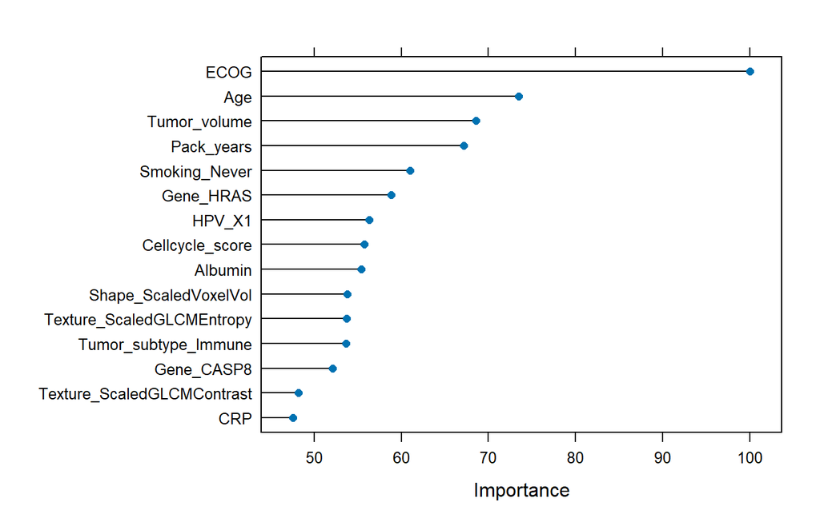

Most important predictors of the final model

```r
vi <- tryCatch(caret::varImp(fit_final), error = function(e) NULL)
if (!is.null(vi)) {
  plot(vi, top = 15)
} else {
  message("Variable importance is not available for this model type.")
}
```

## 10.4 Choosing a decision threshold

The default threshold of 0.5 is not always clinically appropriate. Missing a patient who will die (a false negative) may cost more than a false alarm, so the threshold can be chosen separately from the model.

The threshold is chosen on the **out-of-fold cross-validated predictions** (`fit_final$pred`, kept by `savePredictions = "final"`). Each training patient was predicted by a model that never saw that patient, so these probabilities are honest. Predictions of the final model on its own training patients would be over-confident and would give a biased threshold. Here the threshold maximises Youden’s index (sensitivity + specificity − 1), which weights both error types equally; a clinical application could instead require a minimum sensitivity. The chosen threshold is then evaluated **once** on the test set.

```r
# Out-of-fold predictions of the chosen tuning setting: one row per training patient
oof <- fit_final$pred
stopifnot(nrow(oof) == nrow(tr_DF))

roc_cv <- pROC::roc(oof$obs, oof$Died, levels = c("Survived", "Died"), direction = "<", quiet = TRUE)

thr <- pROC::coords(roc_cv, x = "best", best.method = "youden",
                    ret = "threshold", transpose = FALSE)
thr <- as.numeric(thr$threshold)[1]

# Cross-validated sensitivity / specificity / accuracy at the chosen threshold
cv_at_thr <- pROC::coords(roc_cv, x = thr, input = "threshold",
                          ret = c("sensitivity", "specificity"), transpose = FALSE)
cv_acc <- mean((oof$Died >= thr) == (oof$obs == "Died"))

# Test set: default threshold versus the cross-validated threshold
te_class_thr <- factor(ifelse(te_prob >= thr, "Died", "Survived"), levels = c("Died", "Survived"))
cm_te_thr <- caret::confusionMatrix(te_class_thr, te_DF[[y_col]], positive = "Died")

tibble(Evaluation = c("Cross-validation (threshold chosen here)", "Test, default threshold", "Test, chosen threshold"),
       Threshold   = c(thr, 0.5, thr),
       Sensitivity = c(cv_at_thr$sensitivity, cm_te$byClass[["Sensitivity"]], cm_te_thr$byClass[["Sensitivity"]]),
       Specificity = c(cv_at_thr$specificity, cm_te$byClass[["Specificity"]], cm_te_thr$byClass[["Specificity"]]),
       Accuracy    = c(cv_acc, cm_te$overall[["Accuracy"]], cm_te_thr$overall[["Accuracy"]])) %>%
  kable(digits = 3, caption = "Effect of the decision threshold (chosen on cross-validated predictions)")
```

Effect of the decision threshold (chosen on cross-validated predictions)

| Evaluation | Threshold | Sensitivity | Specificity | Accuracy |
| --- | --- | --- | --- | --- |
| Cross-validation (threshold chosen here) | 0.489 | 0.731 | 0.795 | 0.769 |
| Test, default threshold | 0.500 | 0.598 | 0.845 | 0.745 |
| Test, chosen threshold | 0.489 | 0.608 | 0.796 | 0.720 |

# 11. Discussion

## 11.1 What the dataset implies for modelling

The choice of algorithm should follow the structure of the data. The features of this cohort that matter most are:

**Moderate sample size:** 961 training patients (391 deaths and 570 survivors) for 45 predictors. This is enough for simple and regularised models, but not for very flexible ones, which tend to fit noise.

**Many weak or uninformative predictors:** Roughly half of the genes, SNPs and imaging features carry little independent information about death. Methods that shrink or ignore such predictors have an advantage.

**Correlated blocks:** Gene expression, the derived scores and the radiomics features move together (several pairs with |r| above 0.7, see the correlation plot). Models differ strongly in how they treat redundant information.

**Mostly additive effects:** The main clinical and biological effects act roughly additively on the log-odds of death, with only minor non-linear terms and interactions (the outcome was simulated in `scripts/simulate_hnscc_data.py`). Linear models match this structure; flexible models have to learn it.

**Mixed predictor types:** Continuous, skewed, binary, count (SNP) and ordinal predictors, handled by the recipe (dummy coding, Yeo-Johnson, scaling).

**Mild class imbalance:** About 40.69% of patients died, so a vote-based or threshold-based rule at 0.5 leans towards the majority class (survival).

## 11.2 How the models differ

| Model | Core idea | Decision boundary | Treatment of correlated predictors | Main safeguard against over-fitting | Main risk on this dataset |
| --- | --- | --- | --- | --- | --- |
| `glmnet` | Logistic regression with an elastic-net penalty | Linear in the log-odds | Ridge part shares weight; lasso part selects | `alpha`, `lambda` | Cannot find interactions or non-linear effects |
| `pls` | Regress on a few latent components that maximise covariance with the outcome | Linear | Built for collinearity | Number of components | Scores are not true probabilities; ignores non-linearity |
| `rda` | Gaussian classes; `lambda` blends class-specific and pooled covariances (LDA at 1), `gamma` shrinks towards a diagonal | Linear to quadratic | Models the full covariance | `gamma`, `lambda` | Gaussian assumption; noisy covariances |
| `nb` | Product of marginal class-conditional densities | Non-linear marginals, no interactions | Assumes independence, so double counts | Smoothing, bandwidth | Over-confident probabilities |
| `knn` | Majority vote of the k most similar patients | Local, non-parametric | Redundant predictors inflate distances | `k` | Curse of dimensionality |
| `pam` | Class centroids shrunk by soft-thresholding | Linear (diagonal covariance) | Ignores correlation | Shrinkage threshold | Designed for p much larger than n |
| `gbm` | Sequence of shallow trees fitted to the logistic-loss gradient | Non-linear, interactions | Robust | Depth, shrinkage, trees | Needs many steps to approximate smooth effects |
| `xgbTree` | Regularised boosted trees with sampling | Non-linear, interactions | Robust; column subsampling | `gamma`, `eta`, subsampling, depth | As `gbm`, but more regularised |
| `nnet` | One hidden layer with weight decay | Non-linear | Shared hidden units | Weight decay, few units | Local optima, start-dependent |
| `mlp` | One hidden layer trained by back-propagation | Non-linear | Shared hidden units | Number of units only | Higher variance, random starts |

## 11.3 Model by Model

```r
# Helpers and summary quantities used in the text below
cv_auc <- function(m) if (m %in% cv_tbl$Model)  f3(cv_tbl$ROC[cv_tbl$Model == m])  else "n/a"
te_auc <- function(m) if (m %in% perf_te$Model) f3(perf_te$AUC[perf_te$Model == m]) else "n/a"
tr_auc <- function(m) if (m %in% perf_tr$Model) f3(perf_tr$AUC[perf_tr$Model == m]) else "n/a"

gap_tbl <- cv_tbl %>%
  select(Model, `CV AUC` = ROC, Sensitivity, Specificity) %>%
  left_join(perf_tr %>% select(Model, `Train AUC` = AUC), by = "Model") %>%
  left_join(perf_te %>% select(Model, `Test AUC` = AUC), by = "Model") %>%
  mutate(`Train - CV gap` = `Train AUC` - `CV AUC`,
         `CV - Test gap`  = `CV AUC` - `Test AUC`) %>%
  arrange(desc(`CV AUC`))

best_cv        <- max(cv_tbl$ROC)
near_best      <- cv_tbl$Model[cv_tbl$ROC >= best_cv - 0.01]
worst_model    <- cv_tbl$Model[which.min(cv_tbl$ROC)]
auc_range      <- diff(range(cv_tbl$ROC))
hi_spec_model  <- cv_tbl$Model[which.max(cv_tbl$Specificity)]
lo_sens_model  <- cv_tbl$Model[which.min(cv_tbl$Sensitivity)]
hi_sens_model  <- cv_tbl$Model[which.max(cv_tbl$Sensitivity)]
big_gap_model  <- gap_tbl$Model[which.max(gap_tbl$`Train - CV gap`)]
big_gap        <- max(gap_tbl$`Train - CV gap`)
small_gap_model <- gap_tbl$Model[which.min(gap_tbl$`Train - CV gap`)]
small_gap      <- min(gap_tbl$`Train - CV gap`)
rank_cor       <- cor(gap_tbl$`CV AUC`, gap_tbl$`Test AUC`, method = "spearman")

roc_cols <- grep("~ROC$", names(rs$values), value = TRUE)
fold_sd  <- median(sapply(rs$values[roc_cols], sd))      # typical fold-to-fold SD of the AUC
```

### Penalised and latent-variable linear models

**Elastic-net logistic regression (`glmnet`):** The model is an ordinary logistic regression whose coefficients are shrunk by a mixture of an L1 (lasso) and an L2 (ridge) penalty. The lasso part sets weak coefficients exactly to zero; the ridge part spreads weight across correlated predictors instead of giving all of it to one. This is well matched to the cohort: many predictors are weak, several are redundant, and the strongest effects are additive on the log-odds scale. Shrinkage lowers variance, and the logistic likelihood gives well-calibrated probabilities. Its weakness is that it can only see interactions and non-linear effects if they are supplied. Cross-validated AUC 0.842, test AUC 0.793.

**Partial least squares (`pls`):** Instead of using each predictor separately, PLS builds a small number of latent components, weighted combinations of the predictors that covary most with the outcome, and regresses on them. The gene, score and radiomics blocks collapse onto a few components, which stabilises the fit; a small number of components is usually enough here. Because it is a regularised linear model, its discrimination is close to `glmnet`. It differs in that the component scores are converted into class probabilities by a softmax rule, which are usually less well calibrated than logistic probabilities, and the components are not optimised for the likelihood. Cross-validated AUC 0.842, test AUC 0.781.

### Discriminant and probabilistic models

**Regularised discriminant analysis (`rda`):** Each class (died, survived) is described as a multivariate normal distribution. A new patient is assigned to the class under which the predictors are more likely. The parameter `lambda` blends class-specific covariance matrices (`lambda = 0`, a quadratic boundary) with a single pooled matrix (`lambda = 1`, a linear boundary, as in linear discriminant analysis), and `gamma` shrinks the covariance further towards a diagonal matrix. With 391 deaths and 45 predictors, class-specific covariance matrices are noisy, so a pooled covariance is expected to win. A linear discriminant is nearly equivalent to logistic regression when the class covariances are similar, which explains why `rda` performs close to `glmnet`. The Gaussian assumption is violated by the 0/1 and count predictors, but they carry limited signal, so the cost is small. Cross-validated AUC 0.842, test AUC 0.792.

**Naive Bayes (`nb`)**: Naive Bayes multiplies the class-conditional density of every predictor, estimated here with a kernel smoother, as if the predictors were independent given the outcome. That assumption fails in this cohort: the gene-expression block, the derived scores and the radiomics features are strongly correlated, so the same evidence is counted several times. The result is over-confident probabilities and a weaker ranking of patients. The many uninformative predictors each add a little noise to the product. Cross-validated AUC 0.808, test AUC 0.769.

### Distance- and centroid-based models

**k-nearest neighbours (`knn`):** A patient is classified by a vote among the k most similar training patients in the standardised predictor space. There is no model to fit, and no way to down-weight irrelevant predictors: with 45 dimensions, about half of them uninformative, distances are dominated by noise, and close neighbours are few (the curse of dimensionality). Probabilities are multiples of 1/k, which makes the ranking coarse and limits the AUC. Because most neighbours of an uncertain patient are survivors, the vote leans towards the majority class, which raises specificity and lowers sensitivity at the 0.5 threshold. Cross-validated AUC 0.816, test AUC 0.769.

**Nearest shrunken centroids (`pam`)**: The method computes a centroid for each class and shrinks each predictor’s centroid difference towards zero by a threshold, removing predictors whose difference falls to zero. It then assigns a patient to the nearest centroid. It was designed for gene-expression data with thousands of predictors and few samples, where selection is essential. Here there are far more patients than predictors, so the selection helps little, and the diagonal-covariance assumption ignores the correlation between predictors, as naive Bayes does. Cross-validated AUC 0.803, test AUC 0.769.

### Tree ensembles

**Gradient boosting (`gbm`)**: Shallow trees are added one at a time, each fitted to the errors of the current logistic model, and shrunk by a learning rate. Trees find non-linear effects and interactions automatically and are unaffected by scaling, skewness or outliers. On this cohort, however, the main signal is smooth and additive across many weak predictors, and a piecewise-constant tree needs many steps to approximate a straight-line effect. With fewer than a thousand patients the later trees partly fit noise, so boosting is not expected to beat a penalised linear model and shows a larger gap between training and cross-validated performance. Cross-validated AUC 0.824, test AUC 0.799.

**Extreme gradient boosting (`xgbTree`)**: XGBoost follows the same principle but adds explicit regularisation: penalties on the leaf weights, a minimum gain to make a split (`gamma`), a minimum node weight, and row and column subsampling. These usually make it more resistant to over-fitting than `gbm` on small data. It can exploit the age-by-performance-status interaction, but that interaction is a small part of the signal, so the gain over a linear model is limited. It is run through a custom `caret` model because the built-in method does not work with current `xgboost` releases. Cross-validated AUC 0.830, test AUC 0.789.

### Neural networks

**Single-hidden-layer network (`nnet`)**: A small network combines the predictors into a few hidden units and passes them through a logistic output. Weight decay (an L2 penalty) keeps the weights small, so with few hidden units the model behaves like a regularised logistic regression with some extra flexibility, which explains a performance close to the linear models. It needs scaled inputs (provided by the recipe) and depends on the random starting weights. Cross-validated AUC 0.837, test AUC 0.794.

**Multilayer perceptron (`mlp`)**: The `RSNNS` perceptron is trained by standard back-propagation. In the tuning grid only the number of hidden units is varied, with no weight decay, so the only complexity control is the size of the hidden layer. That means less regularisation and higher variance than `nnet`, and results that depend on random starting weights, which `set.seed()` may not fully control. Its position in the ranking is therefore less reliable. Cross-validated AUC 0.805, test AUC 0.788.

## 11.4 What the performance pattern shows

```r
kable(gap_tbl, digits = 3,
      caption = "Cross-validated, training and test performance of each model (gaps = differences in AUC)")
```

Cross-validated, training and test performance of each model (gaps = differences in AUC)

| Model | CV AUC | Sensitivity | Specificity | Train AUC | Test AUC | Train - CV gap | CV - Test gap |
| --- | --- | --- | --- | --- | --- | --- | --- |
| pls | 0.842 | 0.691 | 0.826 | 0.861 | 0.781 | 0.019 | 0.061 |
| glmnet | 0.842 | 0.652 | 0.835 | 0.871 | 0.793 | 0.029 | 0.049 |
| rda | 0.842 | 0.678 | 0.828 | 0.871 | 0.792 | 0.029 | 0.050 |
| nnet | 0.837 | 0.683 | 0.812 | 0.874 | 0.794 | 0.037 | 0.043 |
| xgbTree | 0.830 | 0.657 | 0.819 | 1.000 | 0.789 | 0.170 | 0.041 |
| gbm | 0.824 | 0.614 | 0.823 | 0.920 | 0.799 | 0.096 | 0.025 |
| knn | 0.816 | 0.534 | 0.905 | 0.842 | 0.769 | 0.026 | 0.048 |
| nb | 0.808 | 0.596 | 0.839 | 0.842 | 0.769 | 0.034 | 0.039 |
| mlp | 0.805 | 0.678 | 0.798 | 0.853 | 0.788 | 0.048 | 0.017 |
| pam | 0.803 | 0.547 | 0.858 | 0.814 | 0.769 | 0.012 | 0.034 |

```r
fam <- c(glmnet = "Linear", pls = "Linear",
         rda = "Discriminant / probabilistic", nb = "Discriminant / probabilistic",
         knn = "Distance / centroid", pam = "Distance / centroid",
         gbm = "Tree ensembles", xgbTree = "Tree ensembles",
         nnet = "Neural networks", mlp = "Neural networks")

fam_tbl <- gap_tbl %>%
  mutate(Family = unname(fam[Model])) %>%
  group_by(Family) %>%
  summarise(Models = paste(Model, collapse = ", "),
            `Mean CV AUC` = mean(`CV AUC`),
            `Mean test AUC` = mean(`Test AUC`),
            `Mean train - CV gap` = mean(`Train - CV gap`),
            .groups = "drop") %>%
  arrange(desc(`Mean CV AUC`))
best_family  <- fam_tbl$Family[1]
worst_family <- fam_tbl$Family[nrow(fam_tbl)]
kable(fam_tbl, digits = 3, caption = "Performance by model family")
```

Performance by model family

| Family | Models | Mean CV AUC | Mean test AUC | Mean train - CV gap |
| --- | --- | --- | --- | --- |
| Linear | pls, glmnet | 0.842 | 0.787 | 0.024 |
| Tree ensembles | xgbTree, gbm | 0.827 | 0.794 | 0.133 |
| Discriminant / probabilistic | rda, nb | 0.825 | 0.780 | 0.031 |
| Neural networks | nnet, mlp | 0.821 | 0.791 | 0.043 |
| Distance / centroid | knn, pam | 0.809 | 0.769 | 0.019 |

**Differences are small:** 4 of the 10 models are within 0.01 AUC of the best (pls, glmnet, rda, nnet). The cross-validated AUC of all models spans only 0.040, while the typical fold-to-fold standard deviation of the AUC is 0.022. Differences between the top models are therefore within noise and should not be over-interpreted.

**Family pattern**: The family with the highest mean cross-validated AUC was **Linear**, and the lowest was **Distance / centroid**. This is consistent with the structure described in section 11.1: with additive effects, correlated predictors and fewer than a thousand patients, models that shrink coefficients or share information across correlated predictors are favoured, and models that treat predictors independently (`nb`, `pam`) or rely on distances in a noisy space (`knn`) are disadvantaged. Flexible models (trees, networks) have no structural advantage because there is little non-linearity to find.

**Over-fitting**: The gap between training and cross-validated AUC was largest for xgbTree (0.170) and smallest for pam (0.012). Flexible models can reproduce the training data closely, which is why their training AUC overstates their performance, while heavily regularised models have small gaps.

**Sensitivity versus specificity**: At the default 0.5 threshold, knn had the highest cross-validated specificity (0.91) and knn the lowest sensitivity (0.53), whereas pls had the highest sensitivity (0.69). A high specificity with a low sensitivity means that a model rarely flags a patient as high-risk. It is a property of where the model sits on its ROC curve, and it can be changed by moving the threshold (section 10.4); the AUC is the fairer comparison.

**Test set versus cross-validation**: The Spearman correlation between the cross-validated and test AUCs across the models is 0.48. The test set has only 239 patients, so its ranking of similar models is noisy, which is why the final model was selected on cross-validation.

## 11.5 Practical considerations

**Interpretability**: `glmnet` provides coefficients and odds ratios; `pls` and `rda` provide weights and discriminant directions; tree ensembles and neural networks need importance measures. When several models perform equally well, the interpretable one is preferable in a clinical setting.

**Calibration**: Logistic-type models give probabilities that can be used directly. Scores from `pls`, `knn`, `pam` and boosted trees are often mis-calibrated and may need recalibration before being read as risks.

**Cost**: `glmnet`, `pls` and `rda` train in seconds; boosted trees and networks require large tuning grids. With no accuracy benefit, the extra cost is not justified.

**Choosing among tied models**: A sensible rule is to choose the simplest model among those within one standard error of the best cross-validated AUC.

## 11.6 Limitations

- The data are synthetic, so this report only illustrates how to apply machine learning models. Its results are not clinical evidence, and the model must not be used to predict outcomes for real patients.
- Only discrimination, calibration and threshold-based metrics were assessed. Survival models (for example Cox regression) use follow-up time and censoring, which a binary five-year outcome ignores.
- Validation was internal only. No external validation on an independent cohort (another hospital, country or time period) was possible, so performance in other populations is unknown.

# 12. Conclusion

Ten classification algorithms were compared with 5-fold cross-validation on a synthetic cohort of 1200 head and neck cancer patients. All models discriminated death within five years well above chance (cross-validated AUC from 0.803 to 0.842), and the leading models differed by less than the fold-to-fold variation. The selected model, **pls**, achieved a cross-validated AUC of 0.842 and an AUC of 0.781 (95% CI 0.723 to 0.840) on the held-out test set. The family with the highest mean cross-validated AUC was Linear; this is consistent with a signal that is mainly additive, correlated predictors and a small sample (section 11.1), conditions that favour regularised models over flexible ones.

# Session information

```r
if (use_parallel) parallel::stopCluster(cl)
```